# JABBA3 user guide

## 9.6 Production function and process deviations

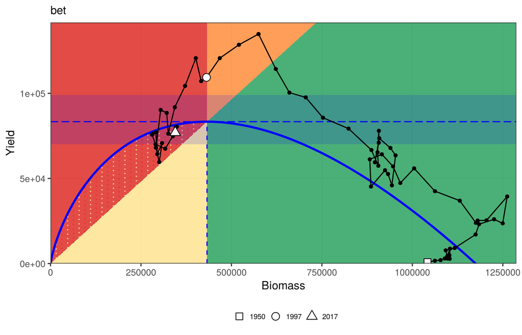

```r
jbplot_spphase(fit)
```

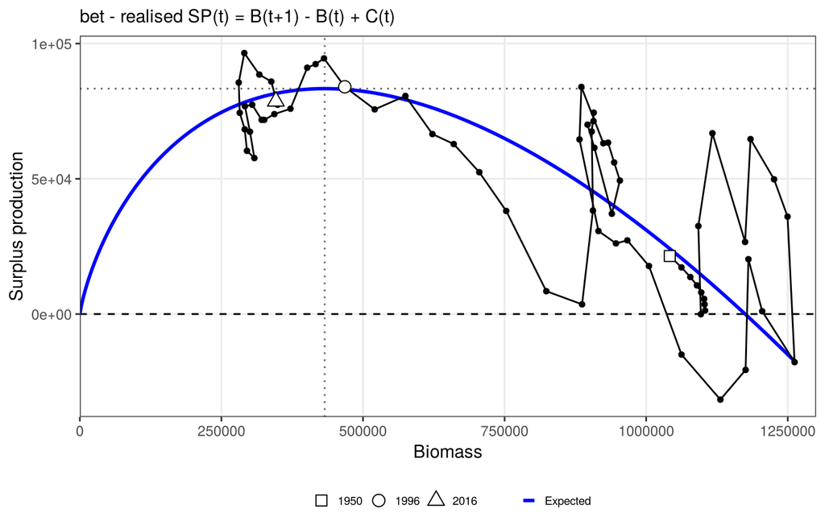

```r
jbplot_spdyn(fit)
```

`jbplot_spphase()` (as JABBA’s `jbplot_spphase()`) plots the catch against biomass over the production curve on the Kobe colours mapped to production space: below the line $C = F_{MSY} B$ the stock is fished below $F_{MSY}$. The hatched band left of $B_{MSY}$ marks catches below the production curve but above that line. `jbplot_spdyn()` plots the realised surplus production, $B_{t+1} - B_t + C_t$, against the expected curve; departures are the process deviations (and the lag) in production units. `rel = TRUE` gives $B/K$ and $C/MSY$ axes, and `jbplot_production(fit, type = "phase" | "dyn")` calls either.

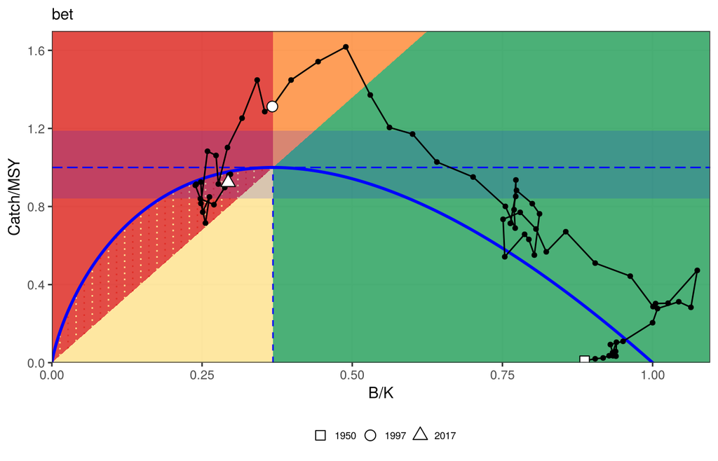

```r
jbplot_production(fit, type = "phase", rel = TRUE)
```

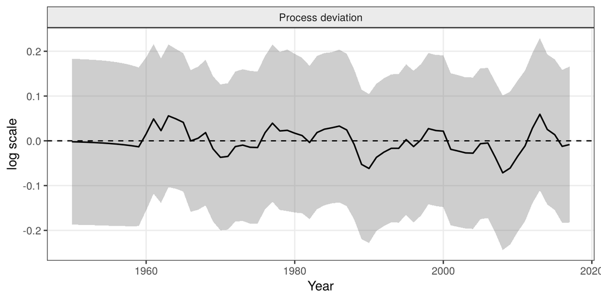

| What | Red flag | Action |
| --- | --- | --- |
| process deviations | long runs of the same sign | persistence: AR(1) with `rho = 0.75` and the lag |
| production plot | catch persistently above the production curve while biomass increases | the production function is wrong for the data: lag, shape, index trends |

```r
jbplot_procdev(fit)
```

## 9.7 Tables

`jb3_partable()` lists parameters, reference points and terminal status with 95% intervals; with a list of fits and `format = "wide"` it compares runs side by side. `jb3_tstable()` gives the time series of estimated quantities by year.

```r
knitr::kable(jb3_partable(fit), digits = 4)
```

| run | par | est | lci | uci | cv |
| --- | --- | --- | --- | --- | --- |
| bet | K | 1174749.3082 | 688737.4984 | 2003718.3113 | 0.2724 |
| bet | r | 0.1929 | 0.1068 | 0.3486 | 0.3019 |
| bet | m | 1.0010 | NA | NA | NA |
| bet | Bmsy/K | 0.3681 | NA | NA | NA |
| bet | Bmsy | 432382.1121 | 253498.9994 | 737495.1825 | 0.2724 |
| bet | Fmsy | 0.1927 | 0.1067 | 0.3483 | 0.3019 |
| bet | MSY | 83335.2568 | 70089.9701 | 99083.5781 | 0.0883 |
| bet | B1/K | 0.8886 | 0.5505 | 1.4344 | 0.2443 |
| bet | sigma.proc | 0.0945 | 0.0631 | 0.1415 | 0.2059 |
| bet | rho | 0.0000 | NA | NA | NA |
| bet | q1 | 0.0000 | 0.0000 | 0.0000 | 0.3174 |
| bet | q2 | 0.0000 | 0.0000 | 0.0000 | 0.3152 |
| bet | sdi1 | 0.0501 | 0.0165 | 0.1526 | 0.5682 |
| bet | sdi2 | 0.0440 | 0.0166 | 0.1165 | 0.4962 |
| bet | B/Bmsy (2017) | 0.7973 | 0.5389 | 1.1795 | 0.1998 |
| bet | F/Fmsy (2017) | 1.1587 | 0.7166 | 1.8734 | 0.2452 |
| bet | B/K (2017) | 0.2934 | 0.1983 | 0.4341 | 0.1998 |

```r
knitr::kable(jb3_partable(list(Fox = fit, Lag.AR1 = rec), format = "wide"))
```

| Parameter | Fox | Lag.AR1 |
| --- | --- | --- |
| K | 1,170,000 (689,000-2,000,000) | 1,360,000 (662,000-2,800,000) |
| r | 0.193 (0.107-0.349) | 0.189 (0.094-0.378) |
| m | 1 | 1 |
| Bmsy/K | 0.368 | 0.368 |
| Bmsy | 432,000 (253,000-737,000) | 502,000 (244,000-1,030,000) |
| Fmsy | 0.193 (0.107-0.348) | 0.188 (0.0939-0.378) |
| MSY | 83,300 (70,100-99,100) | 94,500 (65,200-137,000) |
| B1/K | 0.889 (0.55-1.43) | 0.904 (0.546- 1.5) |
| sigma.proc | 0.0945 (0.0631-0.142) | 0.0866 (0.0543-0.138) |
| rho | 0 | 0.75 |
| q1 | 0.000000907 (0.000000487-0.00000169) | 0.000000831 (0.000000318-0.00000217) |
| q2 | 0.00000171 (0.00000092-0.00000316) | 0.00000154 (0.000000584-0.00000409) |
| sdi1 | 0.0501 (0.0165-0.153) | 0.0488 (0.0165-0.145) |
| sdi2 | 0.044 (0.0166-0.116) | 0.0437 (0.0166-0.115) |
| B/Bmsy | 0.797 (0.539-1.18) | 0.783 (0.403-1.52) |
| F/Fmsy | 1.16 (0.717-1.87) | 1.04 (0.463-2.34) |
| B/K | 0.293 (0.198-0.434) | 0.288 (0.148-0.559) |

```r
knitr::kable(tail(jb3_tstable(fit, c("Catch", "B/Bmsy", "F/Fmsy")), 5), digits = 3)
```

|  | year | Catch | Catch.lci | Catch.uci | B/Bmsy | B/Bmsy.lci | B/Bmsy.uci | F/Fmsy | F/Fmsy.lci | F/Fmsy.uci |
| --- | --- | --- | --- | --- | --- | --- | --- | --- | --- | --- |
| 64 | 2013 | 67455.13 | 54327.76 | 80582.51 | 0.733 | 0.520 | 1.034 | 1.104 | 0.737 | 1.654 |
| 65 | 2014 | 74779.03 | 60214.58 | 89343.48 | 0.782 | 0.554 | 1.104 | 1.148 | 0.761 | 1.731 |
| 66 | 2015 | 80426.90 | 64709.13 | 96144.68 | 0.808 | 0.568 | 1.148 | 1.195 | 0.782 | 1.826 |
| 67 | 2016 | 80080.78 | 64421.70 | 95739.87 | 0.801 | 0.556 | 1.152 | 1.200 | 0.771 | 1.868 |
| 68 | 2017 | 76982.03 | 61893.55 | 92070.51 | 0.797 | 0.539 | 1.180 | 1.159 | 0.717 | 1.873 |

# 10 Check 3: convergence

`jb3_convergence()` follows FLicc: the optimiser code, the largest gradient, a positive definite Hessian, finite standard errors and the Newton decrement (the expected further decrease of the objective by one Newton step). The fit is classed `ok`, `warning` or `failed`.

```r
jb3_convergence(fit)
```

```
#>                       check    value pass
#> 1            optimiser code 0.00e+00 TRUE
#> 2              max gradient 4.44e-12 TRUE
#> 3 Hessian positive definite 1.00e+00 TRUE
#> 4           standard errors 1.00e+00 TRUE
#> 5          Newton decrement 3.02e-25 TRUE
#>                                                                                    meaning
#> 1                                                          nlminb reported convergence (0)
#> 2                                       largest absolute gradient at the optimum (< 0.001)
#> 3                              the mode is a proper minimum (curvature in every direction)
#> 4                                                              all delta-method SEs finite
#> 5 expected further decrease of the objective by a Newton step (< 0.001 ok, <= 0.1 warning)
```

```r
fit$convergence$tier
```

```
#> [1] "ok"
```

| What | Red flag | Action |
| --- | --- | --- |
| max gradient | > 0.001 | refit (`nstart`), check priors and bounds |
| Hessian | not positive definite | a parameter is not identified: priors on r or K, fewer q or variance groups |
| Newton decrement | > 0.1 | not at the optimum; simplify the model |
| estimates at bounds | K at `K.bound`, B/K at `P.bound` | prior-data conflict; revisit priors |

The fit internally polishes the optimum with Newton steps and restarts from jittered values when the gradient is large (`nstart`).

# 11 Check 4: residual diagnostics

## 11.1 One-step-ahead residuals

The residuals of a state-space model computed from the smoothed states are shrunk and autocorrelated by construction, so the classic tests are biased. JABBA3 computes **one-step-ahead (OSA) residuals** (Thygesen et al. 2017) by a particle filter (`jb3_osa()`, run by `jabba3(osa = TRUE)`): each observation is predicted from the data up to the previous one. Under a correct model they are independent N(0, 1).

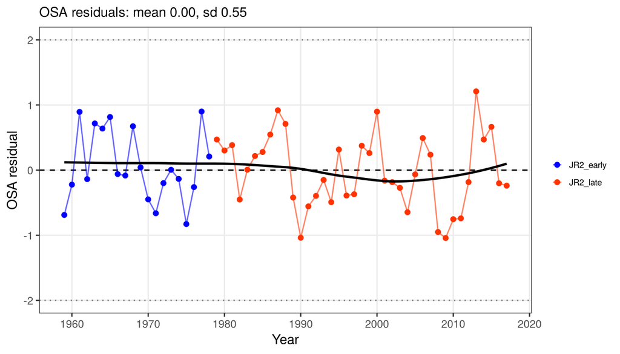

```r
jbplot_residuals(fit)
```

`jbplot_residuals(fit, type = "ordinary")` shows the classic log residuals.

`jbplot_stdresiduals()` shows the ordinary residuals standardised by the total observation SD, as JABBA’s plot of the same name, with SDNR and its 95% critical value:

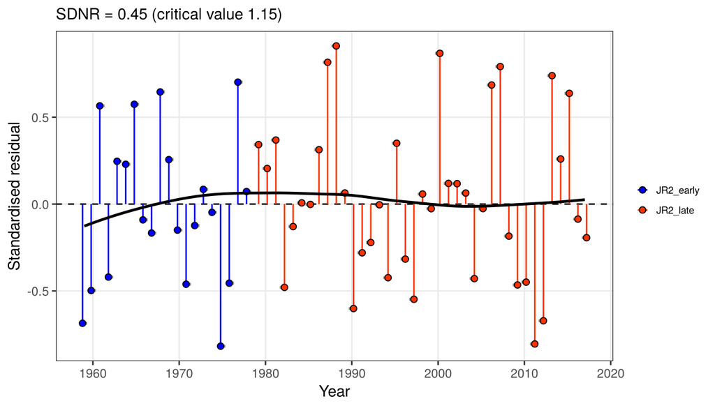

```r
jbplot_stdresiduals(fit)
```

## 11.2 Posterior predictive check

`jbplot_ppc()` compares, draw by draw, the discrepancy of the observed indices from the fitted ones, $D = \sum ((\log I - \log \hat{I})/\sigma)^2$, with that of indices replicated from the observation model (as JABBA’s `jbplot_PPC()`). The Bayesian p-value $P(D^{rep} > D^{obs})$ is near 0.5 for a well-specified observation model; values near 1 mean the indices are fitted more closely than the observation error implies (here the process error absorbs part of the index variation), values near 0 that they are fitted less well. It uses the draws of the fit (NUTS or MVN) and generates MVN draws if there are none.

```r
pp <- jbplot_ppc(fit)
attr(pp, "ppc")
```

```
#>               index Bayesian.p nobs
#> JR2_early JR2_early      0.957   20
#> JR2_late   JR2_late      0.994   39
```

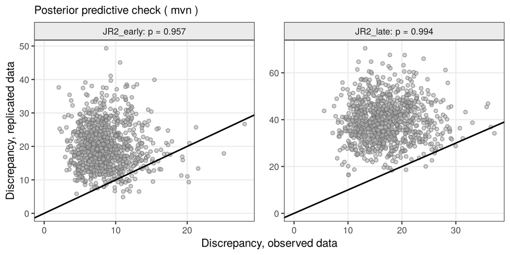

```r
pp
```

## 11.3 Runs tests

The runs test (Wald-Wolfowitz) checks for too few runs of residual signs (autocorrelation), with three-sigma limits from the average moving range (as JABBA, ss3diags and JAGG). Green: passed ($p \ge 0.05$); red: failed.

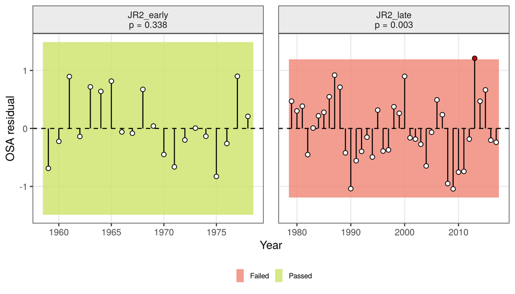

```r
jbplot_runs(fit)
```

The test table is in the plot’s attribute `"runs"` (`attr(jbplot_runs(fit), "runs")`); `mixing = "two.sided"` also flags too many runs. Likewise `jbplot_retro()` and `jbplot_hcxval()` return Mohn’s rho and MASE in attributes `"rho"` and `"mase"`.

## 11.4 The JABBA and SPiCT test sets

`jb3_diags()` gives one table per index: RMSE, SDNR, runs test and the share outside the three-sigma limits (the JABBA set), and the bias t-test, Ljung-Box test (lag 4) and Shapiro-Wilk normality test (the SPiCT set, as `plotspict.diagnostic()`). `flag` is `TRUE` when any test has $p < 0.05$.

```r
jb3_diags(fit)
```

```
#>       index  n       RMSE      SDNR runs.p out.3sig    bias.p  LjungBox.p
#> 1 JR2_early 20 0.09463001 0.5445261  0.338        0 0.6377573 0.662768600
#> 2  JR2_late 39 0.09106039 0.5624106  0.003        0 0.7878223 0.001439274
#>   Shapiro.p  flag
#> 1 0.1168457 FALSE
#> 2 0.6813657  TRUE
```

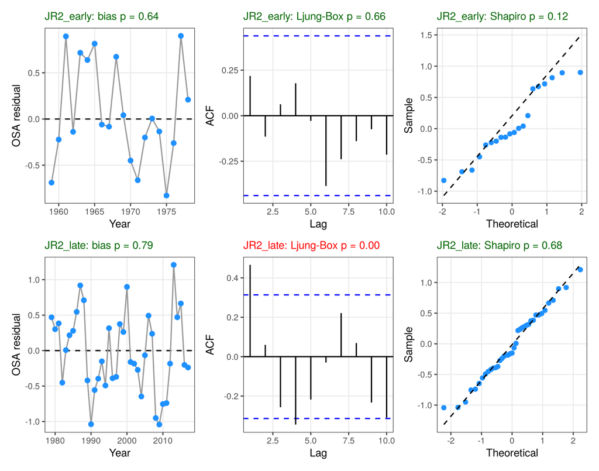

```r
jbplot_spdiags(fit)
```

> Residual tests check the error assumptions; they have little power to detect structural misspecification such as an omitted production lag. Use the retrospective and hindcast as well.

## 11.5 Retrospective analysis

`jb3_retro()` refits with the last 1 to `n` years of all data removed and computes Mohn’s rho.

```r
rt <- jb3_retro(fit, n = 5)
rt$rho
```

```
#>        quantity         rho
#> B             B -0.02622451
#> B/Bmsy   B/Bmsy -0.03492204
#> F             F  0.03281384
#> F/Fmsy   F/Fmsy  0.05993857
```

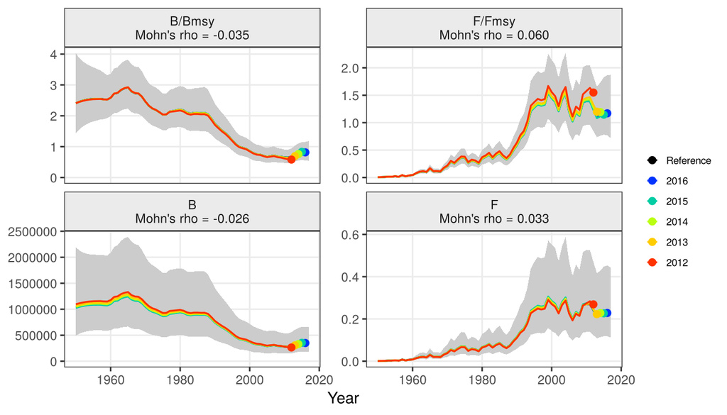

```r
jbplot_retro(rt)
```

## 11.6 Hindcast cross-validation

`jb3_hindcast()` removes the last 1 to `n` years of the indices (catch kept), predicts each removed observation one step ahead, and computes the mean absolute scaled error (MASE; Kell et al. 2021; Carvalho et al. 2021), the prediction error relative to a naive prediction (the last observed value). MASE < 1: the model predicts better than the naive guess.

```r
hc <- jb3_hindcast(fit, n = 5)
hc$mase
```

```
#>               index     MASE MASE.adj   MAE.PR  MAE.base n.eval
#> JR2_early JR2_early       NA       NA       NA        NA      0
#> JR2_late   JR2_late 1.177297 1.177297 0.161752 0.1373927      5
```

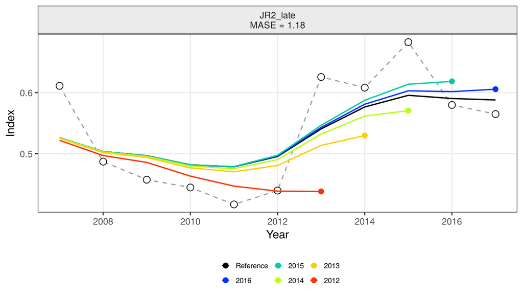

| What | Red flag | Action |
| --- | --- | --- |
| OSA residuals | trends, runs test failed | lag, AR(1), index conflict; separate `sdi` |
| Ljung-Box | p < 0.05 | autocorrelated residuals: process error persistence (AR(1)), or index trends in q |
| Mohn’s rho | beyond -0.15 to 0.20 | retrospective pattern; check recent data and q |
| MASE | > 1 | no prediction skill for that index |

```r
jbplot_hcxval(hc)
```

# 12 NUTS diagnostics

A NUTS fit has to be checked for convergence of the chains before its posterior is used. `jb3_nuts_diags()` gives the rank-normalised split $\hat{R}$, bulk and tail effective sample sizes (ESS; Vehtari et al. 2021) for every sampled parameter, including the states, and the sampler diagnostics by chain: divergent transitions, hits of the maximum tree depth, mean acceptance, step size and the energy Bayesian fraction of missing information (E-BFMI).

```r
nd <- jb3_nuts_diags(fn)
nd$sampler
```

```
#>   chain divergent treedepth.max    accept   stepsize     EBFMI
#> 1     1         0             0 0.9526097 0.05174231 0.5918788
#> 2     2         0             0 0.9446455 0.05372179 0.5475652
#> 3     3         0             0 0.9374562 0.05700973 0.5812739
```

```r
head(nd$pars, 8)
```

```
#>         par       mean        sd       q2.5        q50      q97.5      Rhat
#> 1      logK  3.1731656 0.3059896  2.6426726  3.1516728  3.8134910 1.0019565
#> 2      logr -1.8307025 0.3294560 -2.5274248 -1.8086974 -1.2559005 1.0016879
#> 3   logq[1] -3.0816351 0.3232682 -3.7593970 -3.0634589 -2.5154862 1.0010658
#> 4   logq[2] -2.4908127 0.3359140 -3.1897109 -2.4659187 -1.9009892 1.0024377
#> 5       lbk -0.1479943 0.2131253 -0.5920648 -0.1384202  0.2434195 1.0015750
#> 6    logsdb -2.3027488 0.1925533 -2.7008454 -2.2962544 -1.9323656 1.0024843
#> 7 logsdi[1] -2.9629539 0.4847438 -3.8702378 -2.9668257 -2.0048254 1.0006048
#> 8 logsdi[2] -3.1039285 0.4319932 -3.9334112 -3.0961563 -2.2747392 0.9999395
#>    ess_bulk ess_tail
#> 1 1076.4687 1942.443
#> 2 1314.3005 2479.680
#> 3 1138.5217 2019.079
#> 4  785.7838 1653.940
#> 5 1583.8816 2609.225
#> 6  942.3945 1841.185
#> 7 6026.1418 4668.401
#> 8 7438.3068 5178.916
```

```r
nd$ok
```

```
#> [1] FALSE
```

`ok` is `TRUE` when $\hat{R} < 1.01$, bulk and tail ESS > 100 per chain, there are no divergent transitions and E-BFMI > 0.3 in all chains.

The plots are on the sampled scale (mostly logs): `logK`, `logr`, `logq[i]`, `lbk` (log initial depletion), `logsdb`, `logsdi[i]`, and the states `logP[t]` and catch deviations `cdev[t]`. By default only the fixed effects are plotted; `pars` selects parameters (`"logq"` matches all `logq[i]`).

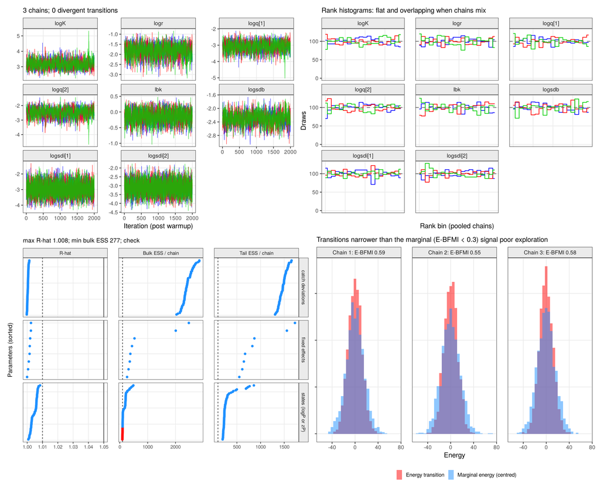

```r
jbplot_nutsdiags(fn)
```

`jbplot_nuts(fit, type)` gives the single plots:

| `type` | Shows | Healthy |
| --- | --- | --- |
| `"trace"` | traces by chain; divergent transitions as red rug ticks | chains overlap, no trends |
| `"rank"` | rank histograms by chain | flat and overlapping |
| `"dens"` | densities by chain | the same in all chains |
| `"acf"` | autocorrelation by chain | drops to zero within a few lags |
| `"pairs"` | pairwise scatter with divergent transitions in red | no funnels or ridges; divergences not clustered |
| `"rhat"` | $\hat{R}$ and ESS for all parameters, states included | $\hat{R} < 1.01$, ESS > 100 per chain |
| `"energy"` | marginal energy against energy transitions | similar widths (E-BFMI > 0.3) |

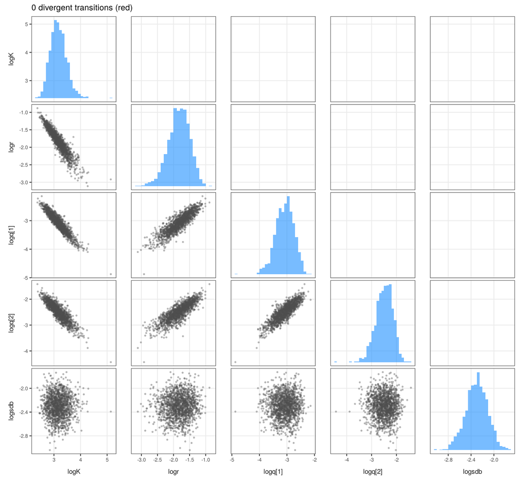

```r
jbplot_nuts(fn, "pairs", pars = c("logK", "logr", "logq", "logsdb"))
```

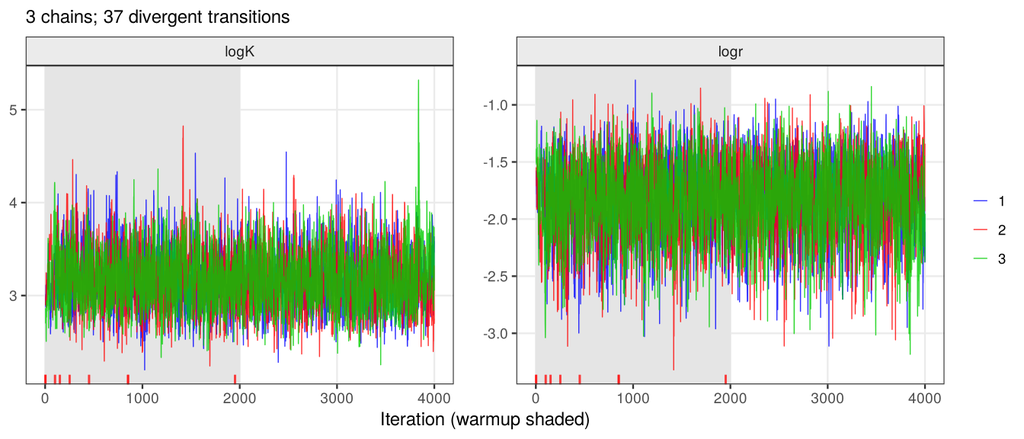

```r
jbplot_nuts(fn, "trace", pars = c("logK", "logr"), inc_warmup = TRUE)
```

Each type is also its own function: `jbplot_trace()`, `jbplot_rank()`, `jbplot_mcmcdens()`, `jbplot_mcmcacf()`, `jbplot_pairs()`, `jbplot_rhat()` and `jbplot_energy()`.

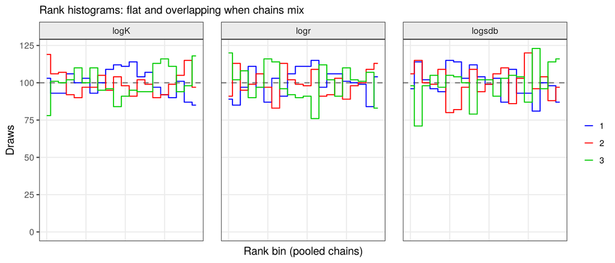

```r
jbplot_rank(fn, pars = c("logK", "logr", "logsdb"))
```

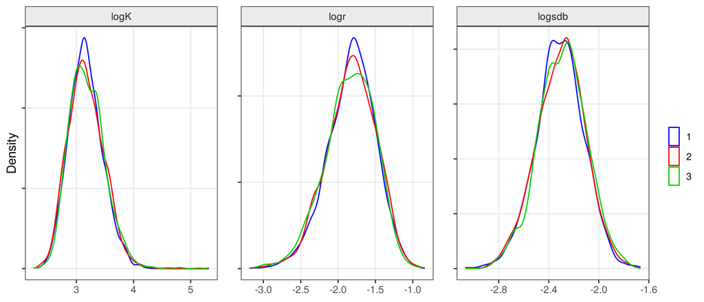

```r
jbplot_mcmcdens(fn, pars = c("logK", "logr", "logsdb"))
```

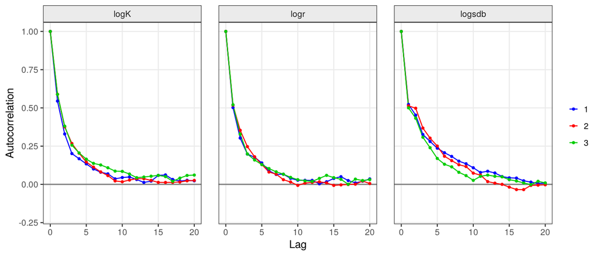

```r
jbplot_mcmcacf(fn, pars = c("logK", "logr", "logsdb"))
```

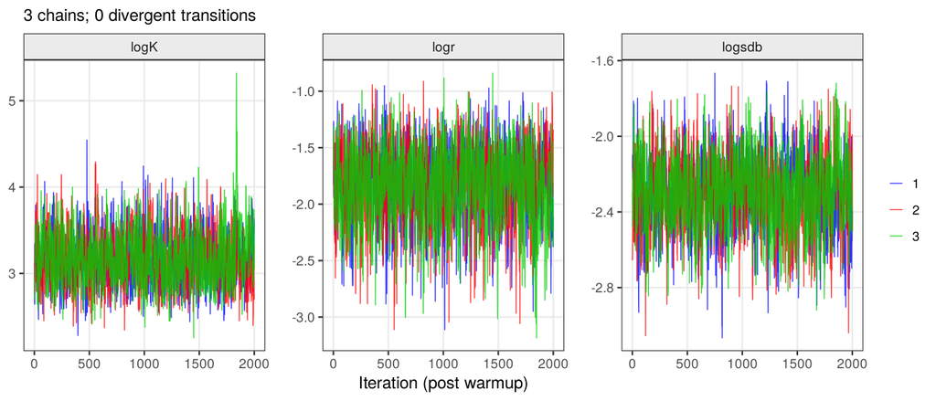

```r
jbplot_trace(fn, pars = c("logK", "logr", "logsdb"))
```

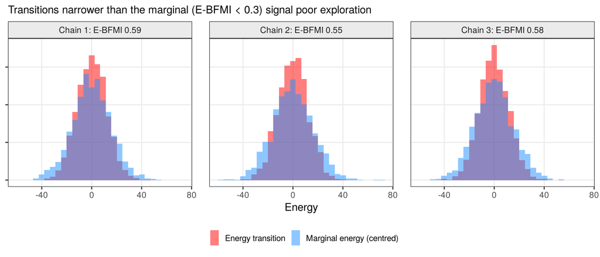

```r
jbplot_energy(fn)
```

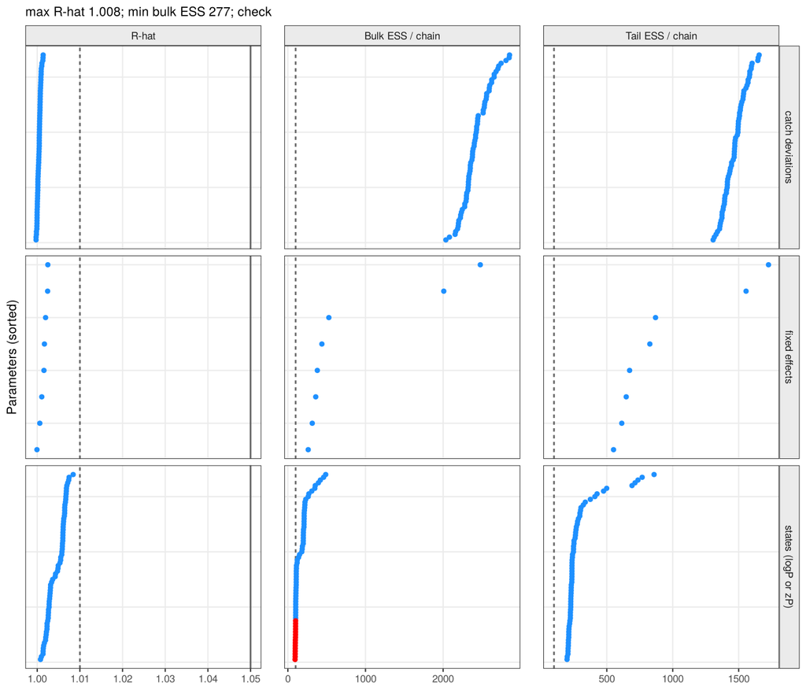

```r
jbplot_rhat(fn)
```

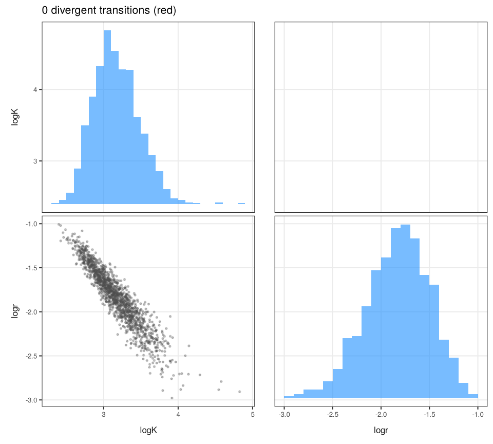

| What | Red flag | Action |
| --- | --- | --- |
| $\hat{R}$, ESS | $\hat{R} > 1.01$ or ESS < 100 per chain | more iterations (`iter`); check the pairs plot |
| divergent transitions | any | `control = list(adapt_delta = 0.99)`; look where they cluster in the pairs plot |
| tree depth | many hits of `max_treedepth` | strong correlations (K and r, K and q): tighter priors |
| E-BFMI | < 0.3 | poor exploration of the tails, often the process error SD and the states |
| K-r-q ridge | strong negative correlation of log K with log r and log q | expected with little contrast; informative r prior |

```r
jbplot_pairs(fn, pars = c("logK", "logr"))
```

> In the short run above the states (`logP`) have low ESS: with process error SDs around 0.1 the states and `logsdb` form a funnel. Run longer for final results.

# 13 BioProcDyn workflows

The workflows of the BioProcDyn protocol run automatically with `jabba3(..., workflow = )`, or step by step with `jb3_tier1()` and `jb3_tier2()` on any fit. All steps are kept in `$steps`.

| `workflow` | Steps |
| --- | --- |
| `"tier1"` | production lag at the age at maturity (`amat`) |
| `"tier2"` | step 1: constant process error (FishLife prior); step 2: dynamic $\sigma_t = \sigma_{MSY} x_t^{-k}$ with the level tuned on step 1, $\sigma_{MSY} = \hat\sigma_1 / \sqrt{\mathrm{mean}(x_{1,t}^{-2k})}$,… |
| `"selex"`, `"selex_tier1"`, `"selex_tier2"` | the same with the spawning-biomass state (needs `model$ebsb`) |

```r
wf <- jabba3(d, pr, jb3_model(shape = "fox"), workflow = "tier2", amat = 3)
names(wf$steps)
```

```
#> [1] "Current" "Tier 2"
```

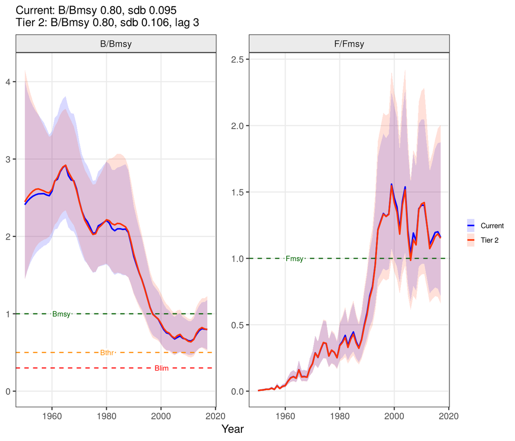

```r
jbplot_steps(wf)
```

Step by step, from an existing fit:

```r
t1 <- jb3_tier1(fit, amat = 3)
t1$model$lag
```

```
#> [1] 3
```

> The BioProcDyn simulations found that the depletion-dependent process error of Tier 2, although present in the operating models, did not remove the optimism; lag + AR(1) (`jb3_model(lag = amat, rho = 0.75)`) did. The tiers are kept for comparison and sensitivity.

# 14 Projections

`jb3_project()` projects the stock under constant $F/F_{MSY}$ scenarios (`fmsy`, the default: 0, 0.5, 0.75, 1 and 1.25 $F_{MSY}$) or constant catch (`catch`), from the NUTS draws or from MVN draws at the mode (generated if the fit has none), with process error (and its AR(1) persistence and the lag). F-based scenarios apply $F = f \times F_{MSY}$ draw by draw, so they remain defined when a draw is depleted; constant catches are capped at 95% of the biomass.

```r
pj <- jb3_project(fit, fmsy = c(0, 0.5, 0.75, 1, 1.25), nyears = 10)
pj$scenarios
```

```
#>     type value         label
#> 1 F/Fmsy  0.00    F/Fmsy = 0
#> 2 F/Fmsy  0.50  F/Fmsy = 0.5
#> 3 F/Fmsy  0.75 F/Fmsy = 0.75
#> 4 F/Fmsy  1.00    F/Fmsy = 1
#> 5 F/Fmsy  1.25 F/Fmsy = 1.25
```

Process error in the projection years follows the fitted model. With the default `procerr = "ar1"`, each draw continues its AR(1) process from its last estimated deviation, $d_{t+1} = \rho d_t + \varepsilon_t$ with $\varepsilon_t \sim N(0, \sigma^2(1-\rho^2))$, so the persistence carries into the forecast and the marginal SD stays $\sigma$ (with $\rho = 0$ this is the iid sampling of JABBA’s `fw_jabba()`). `procerr = "mean"` uses only the conditional mean $\rho^h d_T$ and `"none"` deterministic production. Projection tables report the risk $P(B < B_{lim})$ with $B_{lim} = 0.3 B_{MSY}$ by default.

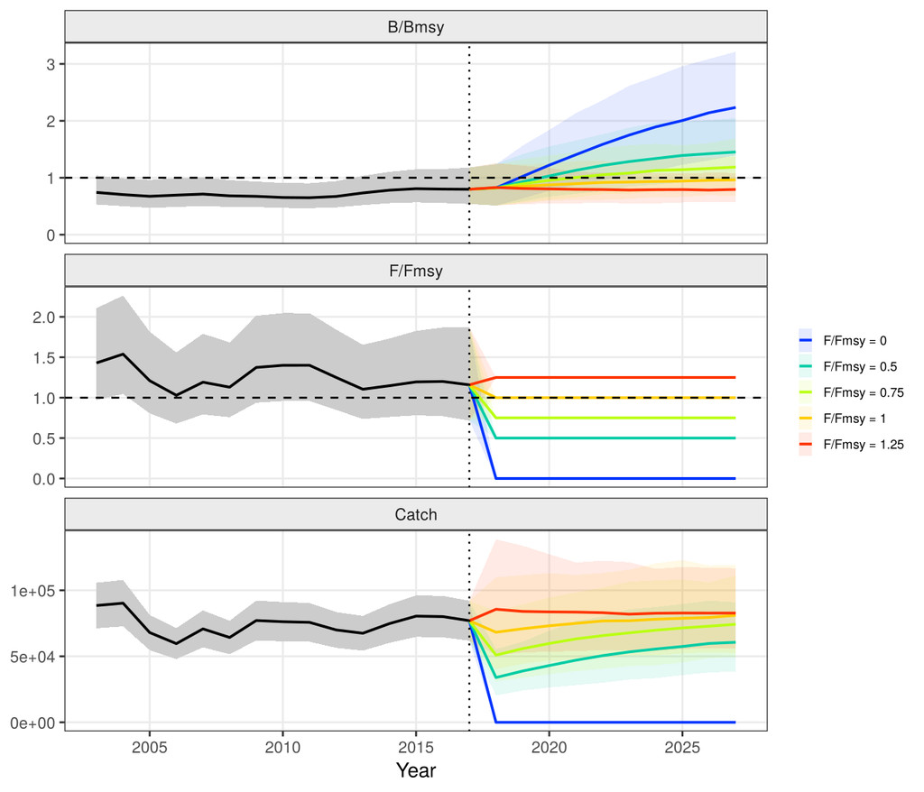

```r
jbplot_projection(pj)
```

## 14.1 Projection tables

`jb3_projtable()` gives a catch options table in the style of an ICES advice sheet: $F/F_{MSY}$, $F$ and the catch in the first projection year, the median $B/B_{MSY}$ in selected years with the change relative to the terminal year, and the probabilities of $B \ge B_{MSY}$, $F \le F_{MSY}$ and of the Kobe green quadrant.

```r
knitr::kable(jb3_projtable(pj, years = c(2018, 2022, 2027)))
```

| scenario | F/Fmsy | F | Catch 2018 | B/Bmsy 2018 | dB% 2018 | P(B>=Bmsy) 2018 | P(B<Blim) 2018 | P(F<=Fmsy) 2018 | P(green) 2018 | B/Bmsy 2022 | dB% 2022 | P(B>=Bmsy) 2022 | P(B<Blim) 2022 | P(F<=Fmsy) 2022 | P(green) 2022 | B/Bmsy 2027 | dB% 2027 | P(B>=Bmsy) 2027 | P(B<Blim) 2027 | P(F<=Fmsy) 2027 | P(green) 2027 |
| --- | --- | --- | --- | --- | --- | --- | --- | --- | --- | --- | --- | --- | --- | --- | --- | --- | --- | --- | --- | --- | --- |
| F/Fmsy = 0 | 0.00 | 0.0000 | 0 | 0.821 | 1.160 | 0.186 | 0 | 1 | 0.186 | 1.590 | 95.40 | 0.959 | 0 | 1 | 0.959 | 2.240 | 175.0 | 0.998 | 0 | 1 | 0.998 |
| F/Fmsy = 0.5 | 0.50 | 0.0964 | 33900 | 0.822 | 1.310 | 0.188 | 0 | 1 | 0.188 | 1.220 | 49.80 | 0.819 | 0 | 1 | 0.819 | 1.450 | 78.9 | 0.972 | 0 | 1 | 0.972 |
| F/Fmsy = 0.75 | 0.75 | 0.1450 | 50900 | 0.819 | 0.884 | 0.188 | 0 | 1 | 0.188 | 1.050 | 29.70 | 0.614 | 0 | 1 | 0.614 | 1.190 | 46.2 | 0.852 | 0 | 1 | 0.852 |
| F/Fmsy = 1 | 1.00 | 0.1930 | 68200 | 0.823 | 1.340 | 0.187 | 0 | 1 | 0.187 | 0.917 | 12.90 | 0.297 | 0 | 1 | 0.297 | 0.963 | 18.7 | 0.416 | 0 | 1 | 0.416 |
| F/Fmsy = 1.25 | 1.25 | 0.2410 | 85600 | 0.829 | 2.140 | 0.187 | 0 | 0 | 0.000 | 0.793 | -2.35 | 0.078 | 0 | 0 | 0.000 | 0.795 | -2.1 | 0.066 | 0 | 0 | 0.000 |

`jb3_kobematrix()` is the Kobe II strategy matrix (ICCAT): the probability of being in the green quadrant by scenario and year (`what = "B"` or `"F"` for one reference point only).

```r
knitr::kable(jb3_kobematrix(pj))
```

|  | scenario | 2018 | 2019 | 2020 | 2021 | 2022 | 2023 | 2024 | 2025 | 2026 | 2027 |
| --- | --- | --- | --- | --- | --- | --- | --- | --- | --- | --- | --- |
| F/Fmsy = 0 | F/Fmsy = 0 | 0.19 | 0.54 | 0.78 | 0.91 | 0.96 | 0.98 | 1.00 | 1.00 | 1.00 | 1.00 |
| F/Fmsy = 0.5 | F/Fmsy = 0.5 | 0.19 | 0.38 | 0.57 | 0.73 | 0.82 | 0.89 | 0.92 | 0.94 | 0.96 | 0.97 |
| F/Fmsy = 0.75 | F/Fmsy = 0.75 | 0.19 | 0.30 | 0.43 | 0.50 | 0.61 | 0.67 | 0.72 | 0.78 | 0.82 | 0.85 |
| F/Fmsy = 1 | F/Fmsy = 1 | 0.19 | 0.21 | 0.24 | 0.27 | 0.30 | 0.32 | 0.36 | 0.37 | 0.38 | 0.42 |
| F/Fmsy = 1.25 | F/Fmsy = 1.25 | 0.00 | 0.00 | 0.00 | 0.00 | 0.00 | 0.00 | 0.00 | 0.00 | 0.00 | 0.00 |

Constant catch scenarios remain available, e.g. for TAC options:

```r
pc <- jb3_project(rec, catch = c(60000, 70000, 80000), nyears = 10)
knitr::kable(jb3_projtable(pc)[, 1:9])
```

| scenario | F/Fmsy | F | Catch 2018 | B/Bmsy 2018 | dB% 2018 | P(B>=Bmsy) 2018 | P(B<Blim) 2018 | P(F<=Fmsy) 2018 |
| --- | --- | --- | --- | --- | --- | --- | --- | --- |
| Catch = 60000 | 0.780 | 0.144 | 60000 | 0.800 | 2.26 | 0.280 | 0.002 | 0.712 |
| Catch = 70000 | 0.909 | 0.169 | 70000 | 0.804 | 2.77 | 0.276 | 0.001 | 0.588 |
| Catch = 80000 | 1.040 | 0.193 | 80000 | 0.801 | 2.30 | 0.282 | 0.002 | 0.465 |

# 15 Comparing runs and risk

## 15.1 Ensembles and sensitivity runs

`jbplot_ensemble()` compares a list of fits (scenarios, sensitivity runs, the steps of a workflow), as JABBA’s plot of the same name: trajectories coloured by run and a Kobe plot with each run’s terminal uncertainty and its median. With `joint = TRUE` the runs are pooled with equal weights into one ensemble.

```r
fsch <- jabba3(d, jb3_priors(d, r = c(0.2, 0.5)), jb3_model(shape = "schaefer"), osa = FALSE)
runs <- list(Fox = fit, Schaefer = fsch, `Lag + AR(1)` = rec)
```

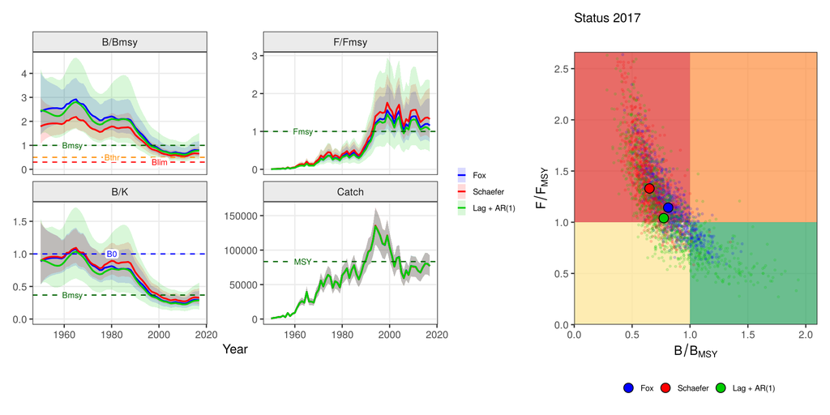

```r
jbplot_ensemble(runs)
```

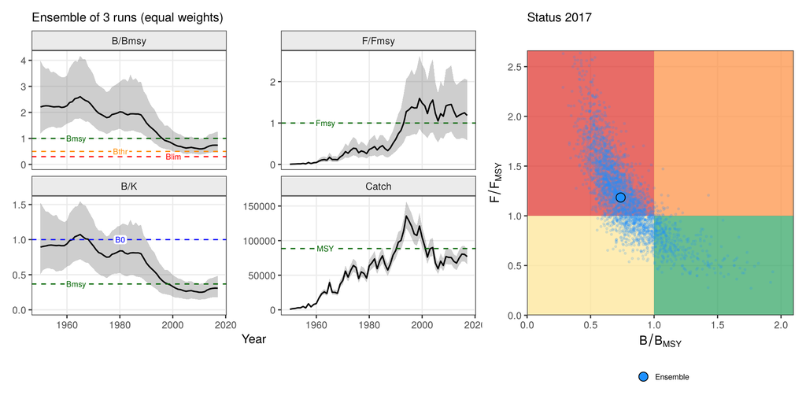

```r
jbplot_ensemble(runs, joint = TRUE)
```

`jbplot_summary()` gives the overview of JABBA’s `jbplot_summary()`: B, F, $B/B_{MSY}$, $F/F_{MSY}$ and $B/K$ by run, and the production curves with $B_{MSY}$ and MSY.

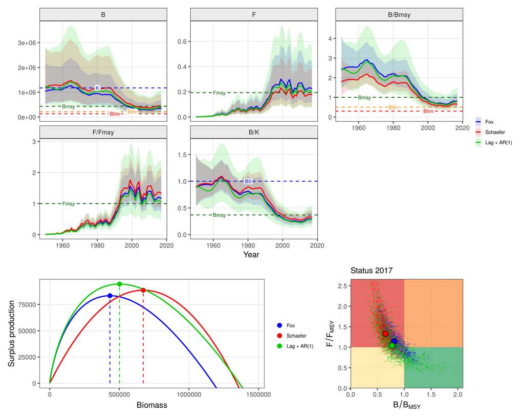

```r
jbplot_summary(runs)
```

`kobe = FALSE` drops the Kobe panel in `jbplot_summary()` and `jbplot_ensemble()`. `jabbaplot3()` takes a list of runs too, with a choice of panels:

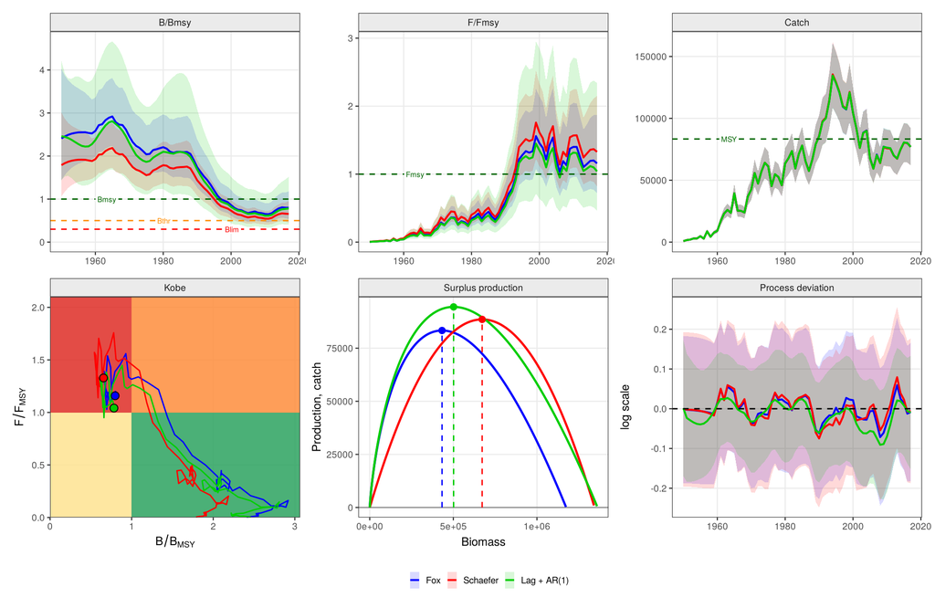

```r
jabbaplot3(runs, panels = c("B/Bmsy", "F/Fmsy", "Catch", "kobe", "production", "procdev"))
```

## 15.2 Projections on the advice plot

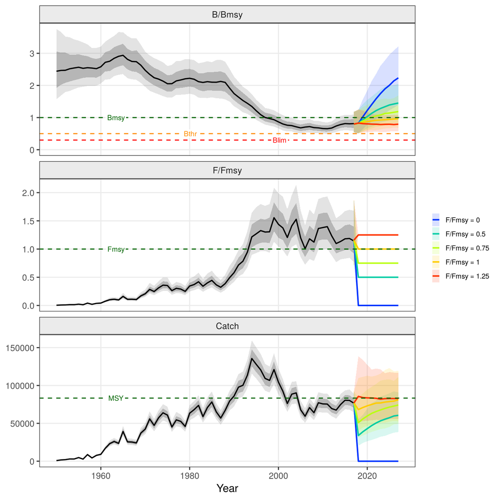

```r
jbplot_advice(fit, proj = pj)
```

## 15.3 Risk curves

`jbplot_crisk()` plots, as JABBA’s `jbplot_Crisk()`, the probability that $B < B_{MSY}$, that $F > F_{MSY}$ and that $B < 0.5 B_{MSY}$ (`bfrac`) against the scenario value (F/F<sub>MSY</sub> or catch), one line per projection year:

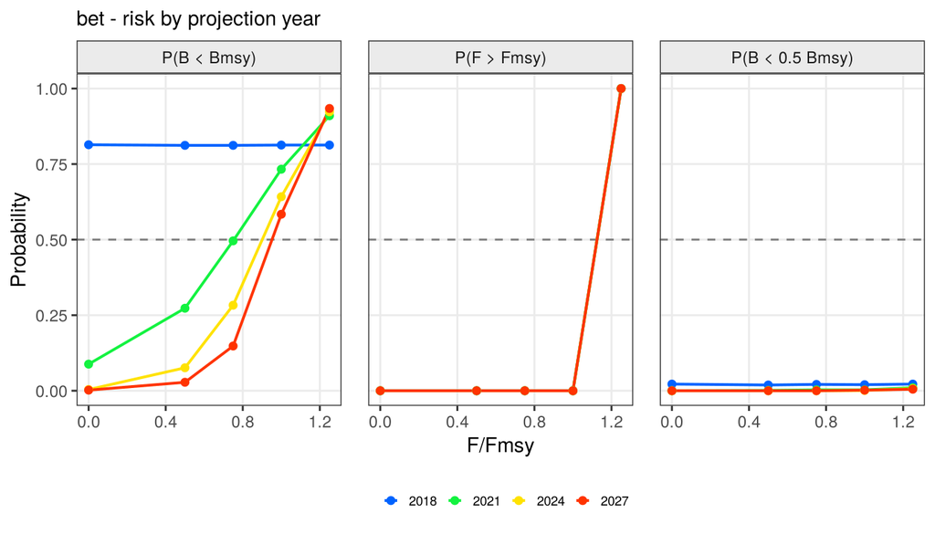

```r
jbplot_crisk(pj)
```

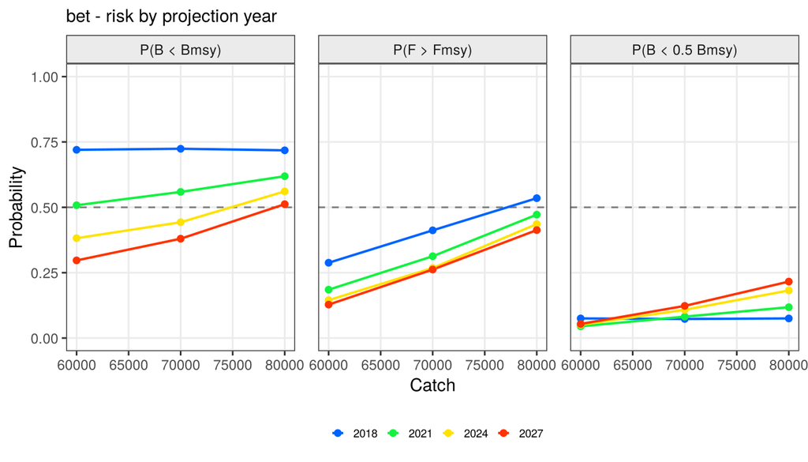

```r
jbplot_crisk(pc)
```

# 16 The rebuilding protocol: Atlantic blue marlin

Bigeye tuna is the standard example of this guide. This chapter is the more complex one: it introduces the BioProcDyn rebuilding protocol on a stock where it matters. The 2018 ICCAT assessment of Atlantic blue marlin (*Makaira nigricans*) used JABBA and Stock Synthesis (SS3), and the two differed markedly in how fast the stock was projected to rebuild. This chapter reproduces the 2018 JABBA base case, applies the BioProcDyn protocol step by step (life-history process error prior, production lag, persistent AR(1) process error) and compares status, diagnostics and forecasts.

## 16.1 The 2018 base case

The 2018 base case was a Pella-Tomlinson model with $B_{MSY}/K = 0.36$, an r prior of 0.098 (CV 0.18), an uninformative K prior, initial depletion near unfished, ten CPUE indices with an additional observation error of 0.25, and the process error fixed at $\sigma = 0.07$ and process deviations starting with the first index year. In JABBA3 (the additional observation variance is estimated by index):

```r
bum <- iccat$bum
d.bum  <- jb3_data(bum$catch, bum$cpue, bum$se, stock = "bum")
pr.bum <- jb3_priors(d.bum, r = c(0.098, 0.18), K = c(50000, sqrt(log(1 + 2^2))),
                     bkinit = c(1, sqrt(log(1 + 0.25^2))))
m.base <- jb3_model(shape = "pella", BmsyK = 0.36, sdb.fixed = 0.07, start = "index")
bum.base <- jabba3(d.bum, pr.bum, m.base, run = "2018 base")
bum.base
```

```
#> JABBA3 fit: 2018 base ( bum )  engine: rtmb
#>   model: pella
#>   convergence: ok (max gradient 1.3e-09, Newton decrement 1.0e-20)
#>   estimates (mode, 95% CI):
#>             est      lci      uci
#> K      9.15e+04 6.83e+04 1.22e+05
#> r      9.47e-02 6.99e-02 1.28e-01
#> bkinit 1.22e+00 1.11e+00 1.35e+00
#> sdb    7.00e-02       NA       NA
#> q1     1.58e-05 1.13e-05 2.21e-05
#> q2     1.60e-05 1.03e-05 2.48e-05
#> q3     3.07e-05 2.11e-05 4.45e-05
#> q4     3.43e-05 2.31e-05 5.09e-05
#> q5     2.57e-05 1.63e-05 4.07e-05
#> q6     2.91e-05 1.79e-05 4.73e-05
#> q7     1.55e-05 1.03e-05 2.33e-05
#> q8     2.54e-05 1.74e-05 3.72e-05
#> q9     3.42e-05 2.24e-05 5.23e-05
#> q10    2.43e-05 1.14e-05 5.16e-05
#> sdi1   1.20e-01 7.17e-02 2.00e-01
#> sdi2   6.65e-01 4.82e-01 9.17e-01
#> sdi3   1.86e-01 9.70e-02 3.56e-01
#> sdi4   2.10e-01 1.29e-01 3.43e-01
#> sdi5   2.12e-01 5.04e-02 8.92e-01
#> sdi6   6.46e-01 4.60e-01 9.08e-01
#> sdi7   6.55e-01 4.94e-01 8.67e-01
#> sdi8   4.04e-01 2.88e-01 5.68e-01
#> sdi9   1.61e-01 1.81e-02 1.42e+00
#> sdi10  9.92e-01 8.20e-01 1.20e+00
#> m      9.58e-01       NA       NA
#> Bmsy   3.29e+04 2.46e+04 4.41e+04
#> Fmsy   9.89e-02 7.30e-02 1.34e-01
#> MSY    3.25e+03 2.70e+03 3.93e+03
#>   status 2016: B/Bmsy 0.78 (0.55-1.13), F/Fmsy 0.80 (0.49-1.29)
```

The same fit follows from the original JABBA input with the converter (`jbinput2jabba3()`, chapter *Converting from JABBA and SPiCT*):

```r
jb.bum <- JABBA::build_jabba(catch = bum$catch, cpue = bum$cpue, se = bum$se,
  assessment = "BUM", scenario = "2018 base", model.type = "Pella", BmsyK = 0.36,
  K.prior = c(50000, 2), r.prior = c(0.098, 0.18), psi.prior = c(1, 0.25),
  fixed.obsE = 0.25, proc.dev.all = FALSE, sigma.proc = 0.07, verbose = FALSE)
x.bum <- jbinput2jabba3(jb.bum, keep.igamma = TRUE)
bum.base <- jabba3(x.bum$data, x.bum$priors, x.bum$model, run = "2018 base")
```

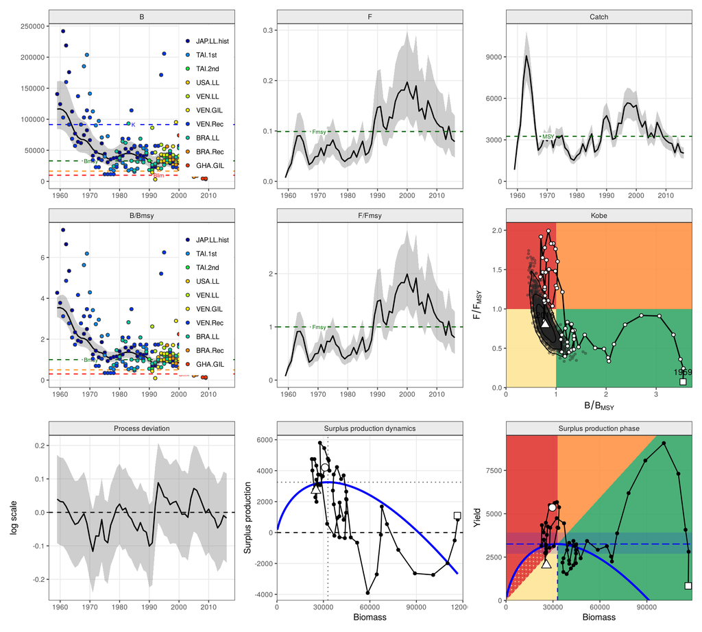

```r
plot(bum.base)
```

The fit is close to the 2018 JAGS assessment. Note the process deviations: with $\sigma$ fixed at a low value they form long runs of the same sign, a lag-1 autocorrelation of

```r
pd <- bum.base$ts$est[bum.base$ts$quantity == "Process deviation"]
round(acf(pd, plot = FALSE)$acf[2], 2)
```

```
#> [1] 0.78
```

This is the persistence that the BioProcDyn simulations identify as the source of rebuilding optimism: a model with independent process error absorbs the persistent part of the production anomalies into r and K.

## 16.2 Joint versus separate indices

Chapter *Data exploration* combined the ten indices into one joint index (`bum.joint`) and found some conflicts among them. Does it matter for the assessment whether the production model is fitted to the ten separate indices or to the joint index? Same priors and settings, the joint index with its own log-scale SE:

```r
if(!exists("bum.joint")) bum.joint <- jb3_jointindex(jb3_trend(bum$cpue, bum$se))
d.joint  <- jb3_data(bum$catch, bum.joint, stock = "bum")
pr.joint <- jb3_priors(d.joint, r = c(0.098, 0.18), K = c(50000, sqrt(log(1 + 2^2))),
                       bkinit = c(1, sqrt(log(1 + 0.25^2))))
bum.ji <- jabba3(d.joint, pr.joint, m.base, run = "joint index")
bum.js <- list(`10 indices` = bum.base, `joint index` = bum.ji)
pt <- jb3_partable(bum.js, format = "wide")
knitr::kable(pt[pt$Parameter %in% c("K", "r", "MSY", "B/Bmsy", "F/Fmsy"), ], row.names = FALSE)
```

| Parameter | 10 indices | joint index |
| --- | --- | --- |
| K | 91,500 (68,300-122,000) | 93,100 (69,400-125,000) |
| r | 0.0947 (0.0699-0.128) | 0.0935 (0.069-0.127) |
| MSY | 3,250 (2,700-3,930) | 3,270 (2,710-3,960) |
| B/Bmsy | 0.784 (0.545-1.13) | 0.775 (0.572-1.05) |
| F/Fmsy | 0.798 (0.494-1.29) | 0.803 (0.52-1.24) |

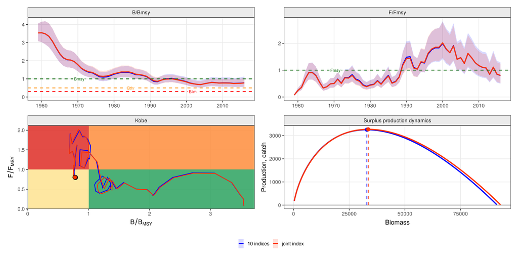

```r
jabbaplot3(bum.js, panels = c("B/Bmsy", "F/Fmsy", "kobe", "spdyn"))
```

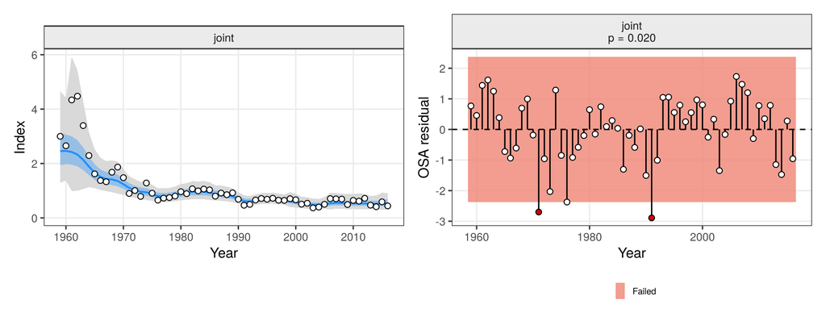

```r
patchwork::wrap_plots(jbplot_fits(bum.ji), jbplot_runs(bum.ji), ncol = 2)
```

```r
dg <- lapply(bum.js, jb3_diags)
knitr::kable(do.call(rbind, lapply(names(dg), function(n) data.frame(run = n, dg[[n]][, c("index", "n", "RMSE", "SDNR", "runs.p", "flag")]))),
             digits = 3, row.names = FALSE, caption = "Residual diagnostics (OSA residuals) by index")
```

Residual diagnostics (OSA residuals) by index

| run | index | n | RMSE | SDNR | runs.p | flag |
| --- | --- | --- | --- | --- | --- | --- |
| 10 indices | JAP.LL.hist | 40 | 0.226 | 1.108 | 0.100 | FALSE |
| 10 indices | VEN.Rec | 40 | 0.718 | 1.008 | 0.002 | TRUE |
| 10 indices | TAI.1st | 22 | 0.684 | 0.991 | 0.001 | TRUE |
| 10 indices | BRA.LL | 28 | 0.453 | 1.053 | 0.389 | FALSE |
| 10 indices | TAI.2nd | 8 | 0.190 | 1.151 | 0.015 | TRUE |
| 10 indices | VEN.LL | 19 | 0.444 | 0.663 | 0.002 | TRUE |
| 10 indices | VEN.GIL | 22 | 0.620 | 0.910 | 0.391 | TRUE |
| 10 indices | USA.LL | 24 | 0.240 | 1.026 | 0.500 | FALSE |
| 10 indices | BRA.Rec | 19 | 0.692 | 1.130 | 0.598 | FALSE |
| 10 indices | GHA.GIL | 10 | 1.055 | 1.074 | 0.004 | TRUE |
| joint index | joint | 58 | 0.199 | 1.087 | 0.020 | TRUE |

Status, reference points and productivity are practically the same: $B/B_{MSY}$ in 2016 of about 0.78 and $F/F_{MSY}$ of 0.80 with either input, and the joint index gives a slightly narrower interval for $B/B_{MSY}$. The ten indices carry one common signal, and the production model extracts the same signal from the joint index. The separate fit flags six of the ten indices on their residual diagnostics; the joint index has a small RMSE (0.20) but its OSA residuals still fail the runs test (p = 0.02), which reflects the low fixed process error of the base case rather than conflict among indices.

The rest of this chapter continues with the ten separate indices, as in the 2018 assessment: each index keeps its own catchability and observation variance, and the diagnostics can still point to individual series. The joint index is a useful check on the combined signal and a simpler alternative where the separate indices are numerous and short.

## 16.3 Applying the protocol

Three steps, each added to the previous one:

1. **Life-history prior on the process error scale** (the JABBA3 default, $\sigma_{MSY} = 0.80 \sigma_R r^{0.45}$) instead of the fixed $\sigma = 0.07$;
2. **production lag** at the age at maturity (here 3 years);
3. **AR(1) process deviations** with $\rho = 0.75$ (the default; blue marlin falls in the 6-10 year generation-time class of `jb3_rho_table()`).

```r
# pr.bum already carries the life-history sdb prior (default); the base case fixed sdb in the model
mod <- function(lag = 0, rho = 0) jb3_model(shape = "pella", BmsyK = 0.36, start = "index", lag = lag, rho = rho)
bum.runs <- list(
  `2018 base`     = bum.base,
  `sdb prior`     = jabba3(d.bum, pr.bum, mod(),        run = "sdb prior"),
  `+ lag`         = jabba3(d.bum, pr.bum, mod(3),       run = "+ lag"),
  `+ lag + AR(1)` = jabba3(d.bum, pr.bum, mod(3, 0.75), run = "+ lag + AR(1)"))
pt <- jb3_partable(bum.runs, format = "wide")
knitr::kable(pt[pt$Parameter %in% c("K", "r", "Bmsy", "Fmsy", "MSY", "sigma.proc", "rho", "B/Bmsy", "F/Fmsy"), ], row.names = FALSE)
```

| Parameter | 2018 base | sdb prior | + lag | + lag + AR(1) |
| --- | --- | --- | --- | --- |
| K | 91,500 (68,300-122,000) | 93,800 (64,100-137,000) | 96,300 (66,400-140,000) | 98,600 (58,000-168,000) |
| r | 0.0947 (0.0699-0.128) | 0.0982 (0.0707-0.137) | 0.0972 (0.0706-0.134) | 0.104 (0.0738-0.146) |
| Bmsy | 32,900 (24,600-44,100) | 33,800 (23,100-49,500) | 34,700 (23,900-50,300) | 35,500 (20,900-60,300) |
| Fmsy | 0.0989 (0.073-0.134) | 0.103 (0.0738-0.143) | 0.101 (0.0737-0.14) | 0.108 (0.077-0.153) |
| MSY | 3,250 (2,700-3,930) | 3,460 (2,590-4,630) | 3,520 (2,650-4,670) | 3,850 (2,400-6,180) |
| sigma.proc | 0.07 | 0.14 (0.102-0.192) | 0.138 ( 0.1-0.191) | 0.117 (0.0762-0.18) |
| rho | 0 | 0 | 0 | 0.75 |
| B/Bmsy | 0.784 (0.545-1.13) | 0.605 (0.403-0.907) | 0.581 (0.376-0.897) | 0.409 (0.209-0.801) |
| F/Fmsy | 0.798 (0.494-1.29) | 0.971 (0.563-1.68) | 0.996 (0.573-1.73) | 1.29 (0.654-2.55) |

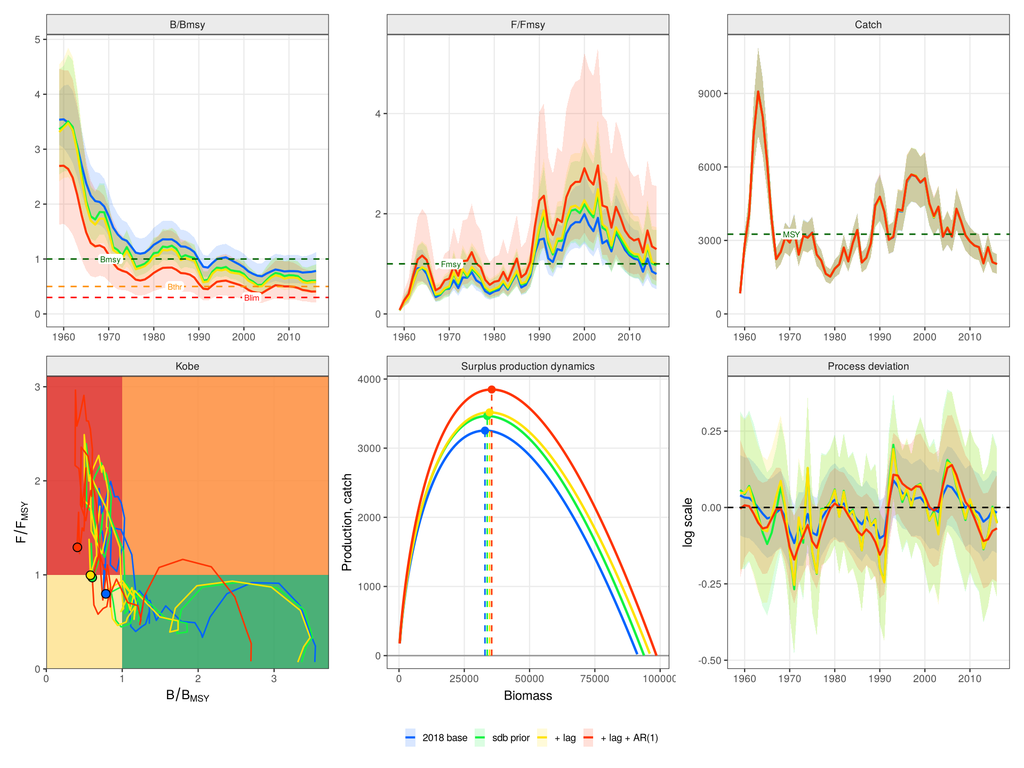

```r
jabbaplot3(bum.runs, panels = c("B/Bmsy", "F/Fmsy", "Catch", "kobe", "spdyn", "procdev"))
```

## 16.4 Diagnostics

Retrospective patterns and index prediction skill do not distinguish the runs; both are acceptable in all of them. As in the simulations, the standard diagnostics cannot tell whether a model is optimistic about rebuilding.

```r
bum.hc <- lapply(bum.runs, jb3_hindcast, n = 5)
bum.rt <- lapply(bum.runs, jb3_retro, n = 5)
mase <- sapply(bum.hc, function(h){ m <- h$mase; stats::setNames(m$MASE, m$index)[is.finite(m$MASE)] })
mohn <- sapply(bum.rt, function(r) stats::setNames(r$rho$rho, r$rho$quantity))
knitr::kable(round(rbind(mase, mohn[c("B/Bmsy", "F/Fmsy"), , drop = FALSE]), 2),
             caption = "Hindcast MASE by index and Mohn's rho")
```

Hindcast MASE by index and Mohn’s rho

|  | 2018 base | sdb prior | + lag | + lag + AR(1) |
| --- | --- | --- | --- | --- |
| BRA.Rec | 0.56 | 0.57 | 0.57 | 0.58 |
| USA.LL | 0.87 | 0.90 | 0.89 | 0.94 |
| VEN.GIL | 0.40 | 0.20 | 0.20 | 0.08 |
| B/Bmsy | 0.09 | 0.08 | 0.08 | 0.07 |
| F/Fmsy | -0.11 | -0.10 | -0.10 | -0.08 |

Hindcasts for the two indices that extend to the end of the series and dominate the recent trend (US and Brazilian recreational/longline CPUE), for the 2018 base case and the protocol:

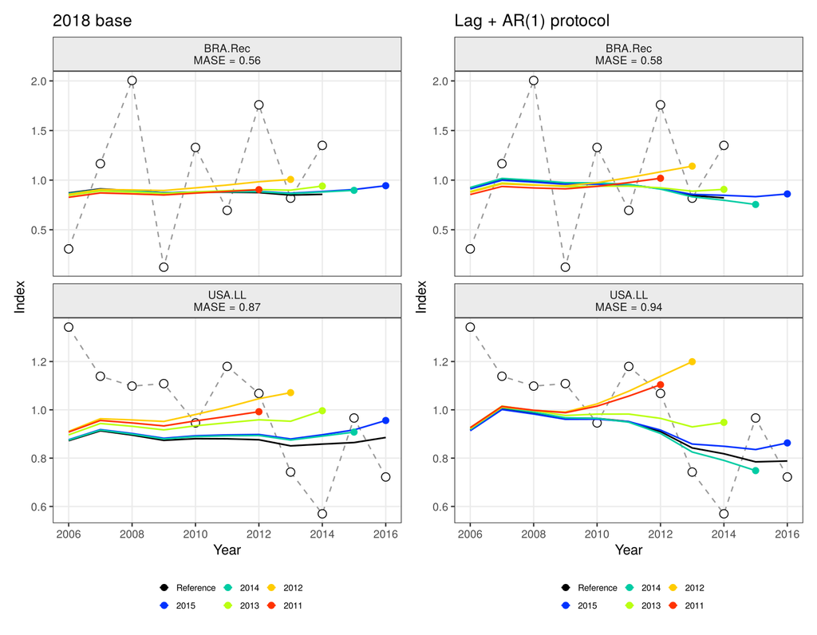

```r
patchwork::wrap_plots(
  jbplot_hcxval(bum.hc$`2018 base`, indices = c("USA.LL", "BRA.Rec"), ncol = 1) + ggplot2::ggtitle("2018 base"),
  jbplot_hcxval(bum.hc$`+ lag + AR(1)`, indices = c("USA.LL", "BRA.Rec"), ncol = 1) + ggplot2::ggtitle("Lag + AR(1) protocol"),
  ncol = 2)
```

## 16.5 Forecasts

The runs differ most in their forecasts. Constant-catch projections of 1500, 2000 and 2500 t, with the AR(1) process continued from the last estimated deviation in the persistent model:

```r
bum.pc <- lapply(bum.runs[c("2018 base", "+ lag + AR(1)")], jb3_project,
                 catch = c(1500, 2000, 2500), nyears = 10)
lapply(bum.pc, function(p) knitr::kable(jb3_kobematrix(p)[, c(1, 2, 4, 6, 11)],
       caption = "P(green) by year"))
```

```
#> $`2018 base`
#>
#>
#> Table: P(green) by year
#>
#> |             |scenario     | 2017| 2019| 2021| 2026|
#> |:------------|:------------|----:|----:|----:|----:|
#> |Catch = 1500 |Catch = 1500 | 0.15| 0.35| 0.56| 0.86|
#> |Catch = 2000 |Catch = 2000 | 0.16| 0.30| 0.48| 0.73|
#> |Catch = 2500 |Catch = 2500 | 0.16| 0.25| 0.35| 0.53|
#>
#> $`+ lag + AR(1)`
#>
#>
#> Table: P(green) by year
#>
#> |             |scenario     | 2017| 2019| 2021| 2026|
#> |:------------|:------------|----:|----:|----:|----:|
#> |Catch = 1500 |Catch = 1500 | 0.01| 0.04| 0.13| 0.36|
#> |Catch = 2000 |Catch = 2000 | 0.01| 0.03| 0.08| 0.26|
#> |Catch = 2500 |Catch = 2500 | 0.01| 0.04| 0.09| 0.21|
```

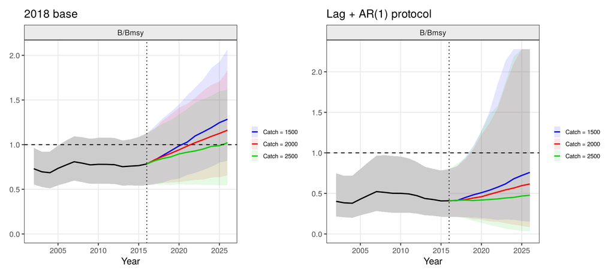

```r
patchwork::wrap_plots(
  jbplot_projection(bum.pc$`2018 base`, type = "B/Bmsy") + ggplot2::ggtitle("2018 base"),
  jbplot_projection(bum.pc$`+ lag + AR(1)`, type = "B/Bmsy") + ggplot2::ggtitle("Lag + AR(1) protocol"))
```

# 17 Other data features

The data-exploration chapter looked at index trends, catchabilities and conflicts among indices of one stock. This chapter covers other common data situations, with two anonymised example datasets:

```r
data(jara_examples)
names(jara_examples)
```

```
#> [1] "areas"   "regions"
```

```r
names(jara_examples$areas)
```

```
#> [1] "catch"  "idx"    "idx.se" "bio"    "bio.se"
```

```r
names(jara_examples$regions)
```

```
#>  [1] "year"      "areaA"     "areaB"     "C.survey1" "C.survey2" "C.cpue1"
#>  [7] "C.cpue2"   "C.cpue3"   "C.cpue4"   "C.cpue5"
```

- `areas`: a catch history from six fleets or areas, two of them with missing early years; relative survey indices with log-SEs for four areas; and swept-area survey biomass for the same four areas;
- `regions`: indices from three regions, a survey each in two adjacent areas (`areaA`, `areaB`) and two surveys and five CPUE series in a third region (`C.*`).

## 17.1 Catch history with missing years

Two fleets report only in the later years (`fleet4`, `fleet5`):

```r
cc <- jara_examples$areas$catch
colSums(!is.na(cc[, -1]))
```

```
#> fleet1 fleet2 fleet3 fleet4 fleet5 fleet6
#>     19     21     24     10     10     26
```

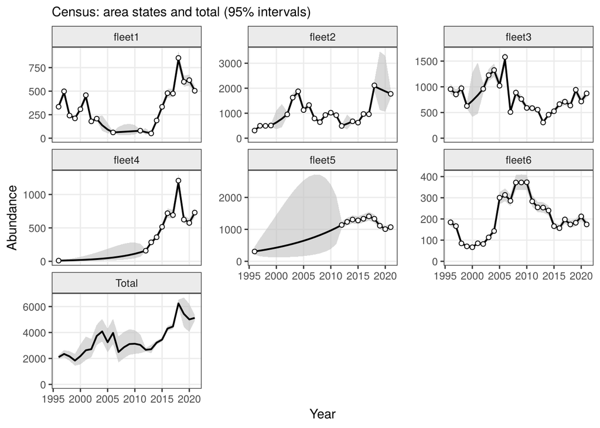

```r
cc[1, "fleet5"] <- cc[1, "fleet2"]; cc[1, "fleet4"] <- 10
sc <- cc; sc[, -1] <- 0.05; sc[1, c("fleet4", "fleet5")] <- 0.2
cf <- jb3_catchfill(cc, se = sc, timeblock = 2016)
jbplot_trend(attr(cf, "fit"))          # fleet fits and the total
```

The total catch with its year-specific log-SE, larger where fleets with assumed start values are interpolated:

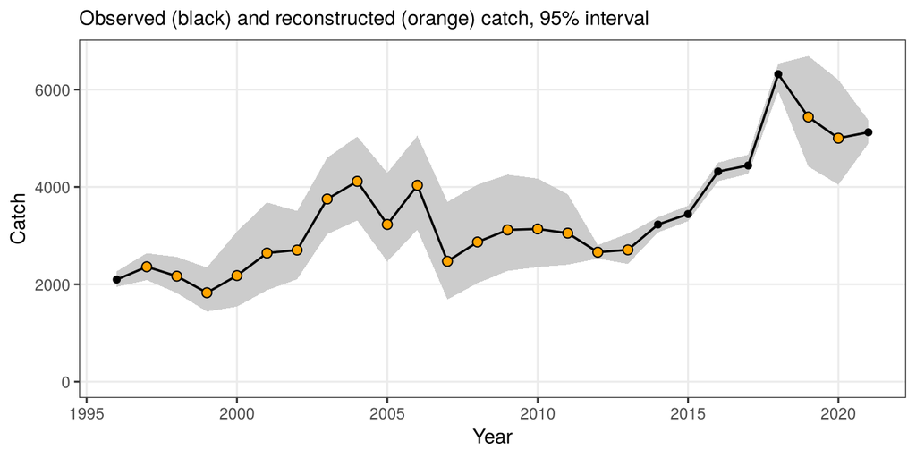

```r
jbplot_catchfill(cf)
```

```r
knitr::kable(as.data.frame(cf)[c(1:3, 15:18, 24:26), c("year", "catch", "se.log", "lci", "uci")],
             digits = 3, row.names = FALSE)
```

| year | catch | se.log | lci | uci |
| --- | --- | --- | --- | --- |
| 1996 | 2097.300 | 0.039 | 1947.461 | 2266.393 |
| 1997 | 2360.185 | 0.060 | 2086.894 | 2639.184 |
| 1998 | 2167.053 | 0.087 | 1822.092 | 2561.615 |
| 2010 | 3137.244 | 0.146 | 2354.137 | 4171.678 |
| 2011 | 3051.221 | 0.120 | 2403.248 | 3850.117 |
| 2012 | 2659.563 | 0.026 | 2528.645 | 2805.143 |
| 2013 | 2707.469 | 0.058 | 2418.475 | 3041.539 |
| 2019 | 5436.590 | 0.106 | 4420.018 | 6690.056 |
| 2020 | 5000.580 | 0.109 | 4047.269 | 6201.394 |
| 2021 | 5123.100 | 0.024 | 4893.222 | 5366.658 |

The filled table, with the original series, the missing values replaced by predictions, and the total:

```r
knitr::kable(head(jb3_fill_table(cf, digits = 1), 6), row.names = FALSE)
```

| year | fleet1 | fleet2 | fleet3 | fleet4 | fleet5 | fleet6 | Total |
| --- | --- | --- | --- | --- | --- | --- | --- |
| 1996 | 334.2 | 307.5 | 954.0 | 10.0 | 307.5 | 184.1 | 2097.3 |
| 1997 | 498.3 | 496.9 | 852.7 | 11.7 | 334.5 | 166.0 | 2360.2 |
| 1998 | 240.6 | 492.8 | 972.1 | 14.0 | 363.0 | 84.6 | 2167.1 |
| 1999 | 210.7 | 508.8 | 626.3 | 16.6 | 393.8 | 70.6 | 1826.9 |
| 2000 | 308.0 | 629.9 | 727.9 | 19.8 | 427.3 | 66.4 | 2179.3 |
| 2001 | 457.3 | 776.9 | 836.5 | 23.5 | 463.6 | 85.1 | 2643.0 |

The reconstructed catch goes into `jb3_data()` with its year-specific SE, which the catch error of the model uses in place of the constant `sdc`; the `jb3catchfill` object can be passed directly as the catch:

```r
d.cf <- jb3_data(cf, jara_examples$areas$idx, jara_examples$areas$idx.se, stock = "areas")
round(range(d.cf$catch.se), 3)
```

```
#> [1] 0.022 0.200
```

## 17.2 Swept-area surveys in several areas

A survey covering four areas gives two kinds of index: relative indices by area (`idx`, with log-SEs) and swept-area biomass estimates (`bio`). The relative indices are combined into a joint index as in the data-exploration chapter:

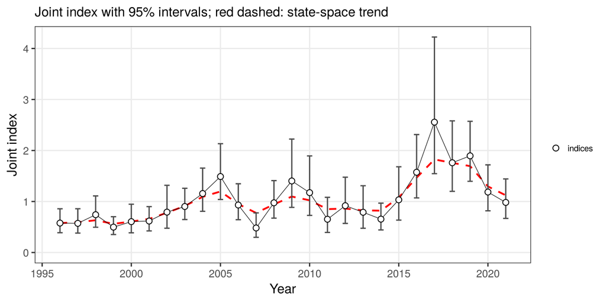

```r
a <- jara_examples$areas
ji.a <- jb3_trend(a$idx, a$idx.se, run = "relative")
jdx.a <- jb3_jointindex(ji.a)
jbplot_jointindex(ji.a)
```

The swept-area estimates are absolute and additive over areas, so a census model fits each area separately and sums the area states to a total biomass with uncertainty, smoothing through years with missing surveys:

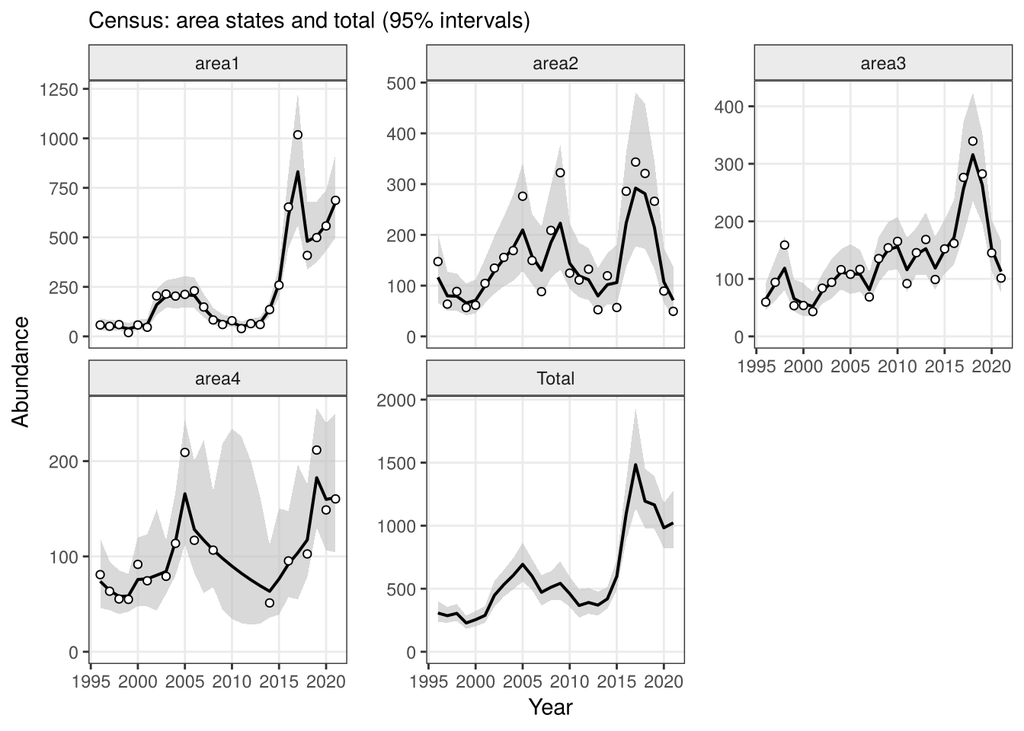

```r
bi <- jb3_trend(a$bio, a$bio.se, type = "census", run = "swept-area census")
jbplot_trend(bi)
```

The census total and the relative joint index, both scaled to their means:

```r
tb <- bi$total
sc1 <- mean(jdx.a$index, na.rm = TRUE); sc2 <- mean(tb$est)
cmp2 <- rbind(data.frame(year = jdx.a$year, index = jdx.a$index/sc1, lci = jdx.a$lci/sc1, uci = jdx.a$uci/sc1,
                         series = "relative joint index"),
              data.frame(year = tb$year, index = tb$est/sc2, lci = tb$lci/sc2, uci = tb$uci/sc2,
                         series = "census total biomass"))
round(cor(log(jdx.a$index), log(tb$est[match(jdx.a$year, tb$year)]), use = "complete.obs"), 2)
```

```
#> [1] 0.87
```

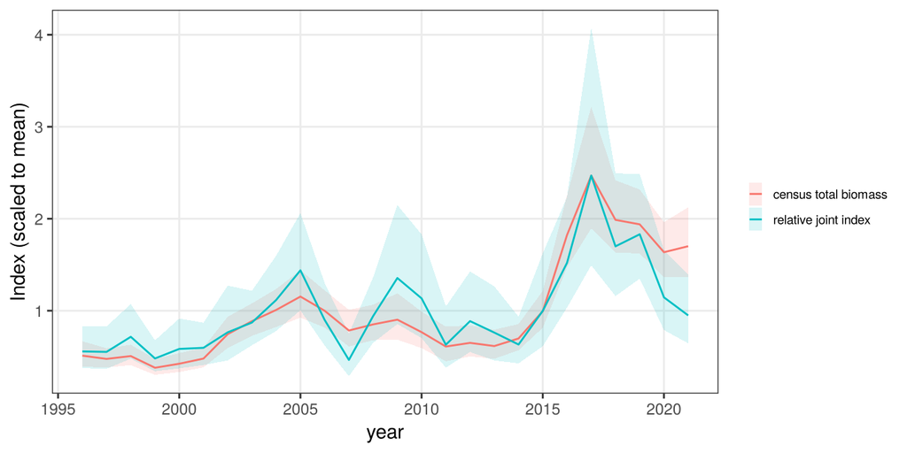

```r
ggplot2::ggplot(cmp2, ggplot2::aes(year, index, colour = series, fill = series)) +
  ggplot2::geom_ribbon(ggplot2::aes(ymin = lci, ymax = uci), alpha = 0.15, colour = NA) + ggplot2::geom_line() +
  ggplot2::labs(y = "Index (scaled to mean)", colour = NULL, fill = NULL) + theme_jabba3()
```

The two agree closely. They answer different questions, however: the joint index weights areas by the precision of their indices, the census total by their biomass, so an area with much of the biomass but a noisy index counts more in the census. Where the trends differ, the census total is the better measure of the whole stock; it can also go into the production model as an index of its own, with the log-SE of the census total.

## 17.3 Do indices among areas conflict? Stock structure

When indices come from several regions, the question is whether they follow a common trend, in which case the regions can be assessed together, or diverge, which may point to separate stocks or at least to regions with different dynamics. The `regions` data have surveys of two adjacent areas and seven indices of a third region C:

```r
rg <- jara_examples$regions
colSums(!is.na(rg[, -1]))
```

```
#>     areaA     areaB C.survey1 C.survey2   C.cpue1   C.cpue2   C.cpue3   C.cpue4
#>        33        24        28        21        32        14        18        26
#>   C.cpue5
#>         6
```

**Within regions.** First the joint index of each region: A and B together (adjacent areas), and C:

```r
tr.AB <- jb3_trend(rg[, c("year", "areaA", "areaB")], run = "A + B")
tr.C  <- jb3_trend(rg[, c("year", grep("^C\\.", names(rg), value = TRUE))], run = "C")
tr.C
```

```
#> JABBA3 trend fit (relative): C
#>   indices: C.survey1, C.survey2, C.cpue1, C.cpue2, C.cpue3, C.cpue4, C.cpue5 | years 1991 - 2023
#>   convergence: ok (max gradient 2.8e-11)
#>   process SD = 0.225
#>   drift r:
#>           trend
#> 1991-2023 0.023
#>      index      q    sdi
#>  C.survey1 1.0000 0.5610
#>  C.survey2 0.6080 0.2920
#>    C.cpue1 1.0500 0.0508
#>    C.cpue2 1.4400 0.0941
#>    C.cpue3 0.0662 0.1750
#>    C.cpue4 0.3300 0.0618
#>    C.cpue5 0.5010 0.0706
```

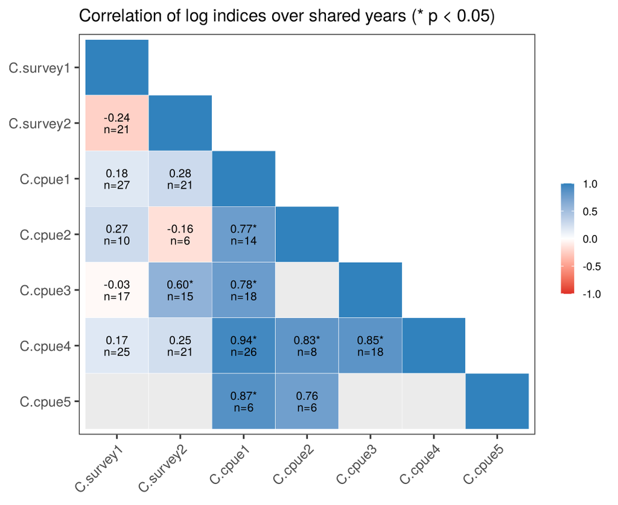

```r
jbplot_indexcor(tr.C)
```

The five CPUE series of region C are strongly correlated (r 0.77-0.94); the two surveys are noisier and agree less with each other and with the CPUE (the large `sdi` values). Within region C, the indices share one trend.

**Between regions.** The joint indices of the two regions on one plot, and their correlation:

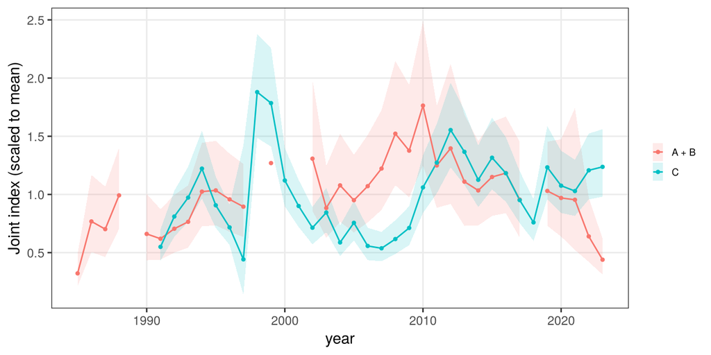

```r
jAB <- jb3_jointindex(tr.AB, name = "A + B"); jC <- jb3_jointindex(tr.C, name = "C")
reg <- rbind(data.frame(jAB, region = "A + B"), data.frame(jC, region = "C"))
reg <- do.call(rbind, lapply(split(reg, reg$region), function(z){ m <- mean(z$index, na.rm = TRUE)
  z$index <- z$index/m; z$lci <- z$lci/m; z$uci <- z$uci/m; z }))
ggplot2::ggplot(reg, ggplot2::aes(year, index, colour = region, fill = region)) +
  ggplot2::geom_ribbon(ggplot2::aes(ymin = lci, ymax = uci), alpha = 0.15, colour = NA) +
  ggplot2::geom_line() + ggplot2::geom_point(size = 0.8) +
  ggplot2::labs(y = "Joint index (scaled to mean)", colour = NULL, fill = NULL) + theme_jabba3()
```

```r
J <- merge(data.frame(year = jAB$year, AB = jAB$index), data.frame(year = jC$year, C = jC$index))
ok <- is.finite(J$AB) & is.finite(J$C)
cor.test(log(J$AB[ok]), log(J$C[ok]))[c("estimate", "p.value")]
```

```
#> $estimate
#>        cor
#> 0.05500221
#>
#> $p.value
#> [1] 0.7768844
```

**All indices in one model.** If the regions were one stock, a single trend model with all nine indices should fit them without systematic residuals. The pairwise correlations and residual diagnostics of the joint fit:

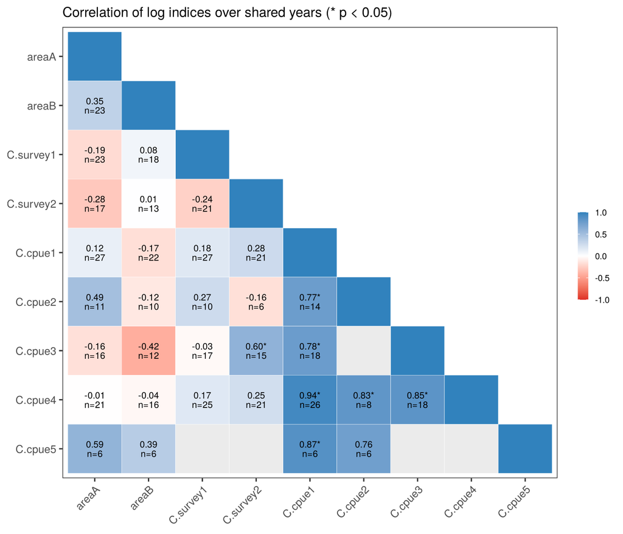

```r
tr.all <- jb3_trend(rg, run = "all regions")
jbplot_indexcor(tr.all)
```

The additional observation SD each index needs, fitted within its region and in the model with all regions:

```r
sdi <- function(f) stats::setNames(f$sdi, f$indices)
knitr::kable(data.frame(index = tr.all$indices, within.region = c(sdi(tr.AB), sdi(tr.C))[tr.all$indices],
                        all.regions = sdi(tr.all)), digits = 3, row.names = FALSE)
```

| index | within.region | all.regions |
| --- | --- | --- |
| areaA | 0.075 | 0.290 |
| areaB | 0.233 | 0.386 |
| C.survey1 | 0.561 | 0.544 |
| C.survey2 | 0.292 | 0.282 |
| C.cpue1 | 0.051 | 0.058 |
| C.cpue2 | 0.094 | 0.081 |
| C.cpue3 | 0.175 | 0.256 |
| C.cpue4 | 0.062 | 0.076 |
| C.cpue5 | 0.071 | 0.071 |

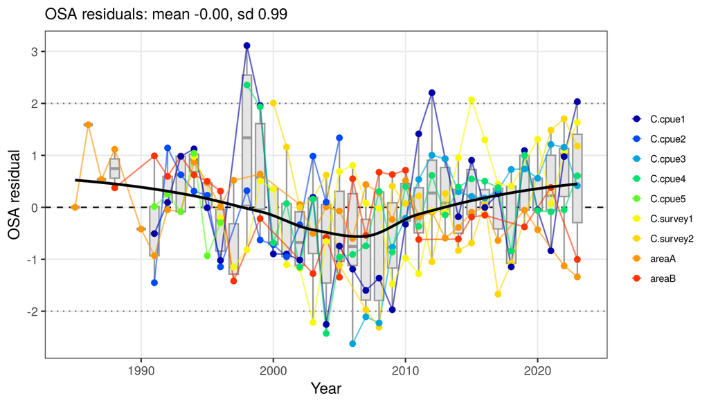

```r
jbplot_residuals(tr.all)
```

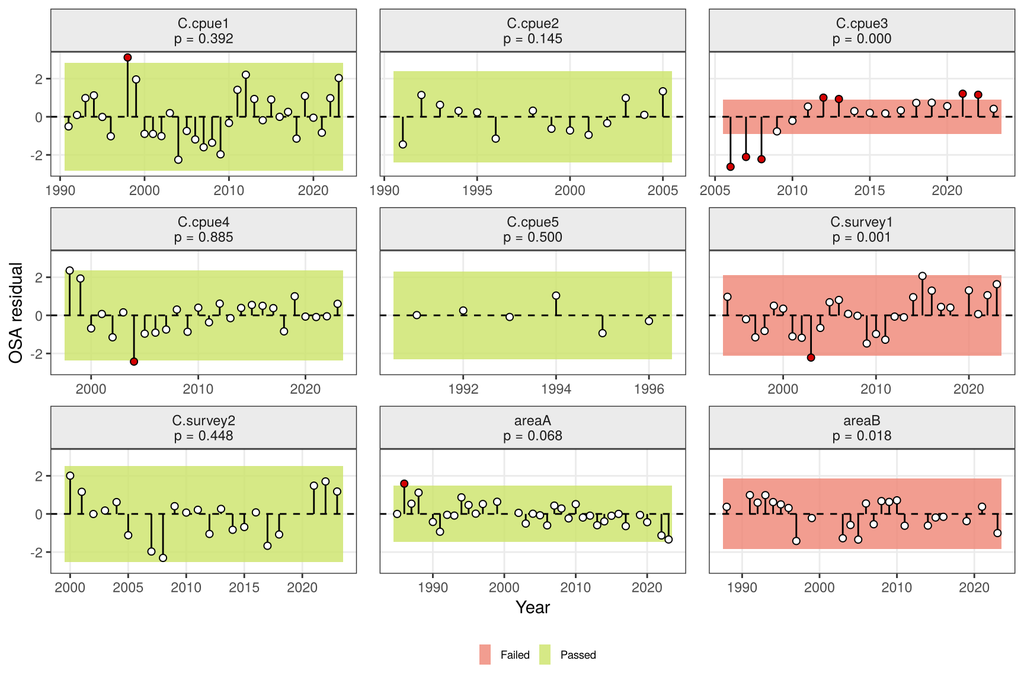

```r
p.reg <- jbplot_runs(tr.all)
p.reg
```

```r
attr(p.reg, "runs")[, c("index", "p.runs", "test")]
```

```
#>               index p.runs   test
#> areaA         areaA  0.068 Passed
#> areaB         areaB  0.018 Failed
#> C.survey1 C.survey1  0.001 Failed
#> C.survey2 C.survey2  0.448 Passed
#> C.cpue1     C.cpue1  0.392 Passed
#> C.cpue2     C.cpue2  0.145 Passed
#> C.cpue3     C.cpue3  0.000 Failed
#> C.cpue4     C.cpue4  0.885 Passed
#> C.cpue5     C.cpue5  0.500 Passed
```

**How to use this.** Agreement among regions (positive correlations, no residual patterns that separate the regions, similar trends in the regional joint indices) supports assessing the regions together with one joint index or with all indices in one model. Conflict between regions, while the indices within each region agree, suggests that the regions have different dynamics: assess them separately, or at least test the combined assessment against separate ones. The trend models cannot by themselves establish stock structure, which needs biological evidence (genetics, tagging, life history), but they show whether the abundance data are consistent with a single unit.

# 18 Special feature: catch-only assessment and auxiliary data

Most stocks have no reliable abundance index. This chapter shows how JABBA3 handles the data-limited end of the range: catch-only assessments with priors on stock status, auxiliary data such as fishing effort or an index of exploitation, and how each kind of data changes the estimate of stock status.

> **The effort and F/Fmsy series used here are hypothetical.** Bigeye tuna has no effort or F/Fmsy series in the package. Both series below (`iccat$bet$effort_hyp` and `iccat$bet$ffmsy_hyp`) were *simulated* from the F trajectory of the bigeye example fit: effort with 2% annual effort creep and lognormal noise (SD 0.15), and F/Fmsy with noise (SD 0.3) for 1990-2009 only. They are not real data. They are used only to show the methods, and their fits are partly circular, because they were simulated from an assessment that used the same catch.

## 18.1 Concept: hierarchical assessment framework

Kell et al. (2025) set out a *hierarchical assessment framework* (HAF) for biomass dynamic models, in which the assessment method follows the data available. There are four tiers:

| Tier | Data | Method |
| --- | --- | --- |
| Robust quantitative assessment | reliable abundance indices and catch | JABBA |
| Preliminary quantitative assessment | partial or short indices, catch | JABBA with scenarios and sensitivity runs |
| Auxiliary data | auxiliary indices (length-based F/Fmsy, effort), catch | auxiliary data as priors or as time series of exploitation |
| Data-limited | catch only | catch-only model with predictive priors (e.g. current depletion) |

The aim is *risk equivalence*: the risk of misclassifying stock status against $B_{MSY}$ and $F_{MSY}$ should be the same in every tier. It is measured by classification skill, for example the true skill statistic (sensitivity + specificity - 1) for $B < B_{MSY}$ or $F > F_{MSY}$. Each tier starts from *prior predictive modelling* (PPM): the model is run with the priors and the catch but without the data, as a reality check of what the assumptions alone imply. Kell et al. found that auxiliary F/Fmsy indices, especially from periods of high exploitation, substantially improve the classification of status.

JABBA3 covers all tiers with one model:

- `jb3_data(catch, indices = NULL)` gives a catch-only data set;
- `jb3_priors(status = jb3_bprior(...))` adds priors on $B/B_{MSY}$, $B/K$ or $F/F_{MSY}$ in any year, as JABBA’s `b.prior`;
- `jb3_data(auxiliary = , auxiliary.type = )` adds auxiliary series of type `"effort"`, `"f"`, `"ffmsy"`, `"bbmsy"`, `"bk"` or `"z"`;
- `jabba3(..., prior.only = TRUE)` switches off the likelihood of the indices and auxiliary data (the catch still drives the dynamics), which gives the prior predictive run.

Without an index, the posterior mode and its Laplace approximation are unreliable: there is nothing to pin down the states. `jabba3()` therefore samples with NUTS by default when there is no index or when `prior.only = TRUE` (`engine = "rtmb"` can still be set explicitly).

The runs below move up the tiers for bigeye tuna:

1. catch only (tier 4): the prior predictive run, then the same with a terminal-year $B/B_{MSY}$ prior;
2. catch + auxiliary data (tier 3): hypothetical effort with 2% creep (and a no-creep sensitivity), and a hypothetical F/Fmsy index from a period of high exploitation;
3. catch + index (tier 1): the two Japanese longline CPUE series;
4. catch + auxiliary data + index.

All runs use the Fox model with the r prior of the bigeye example, the default K and initial depletion priors, and NUTS with three chains of 4000 iterations (2000 warm-up; the `jabba3()` default).

```r
bet <- iccat$bet
pr.r <- c(0.2, 0.5)
mod  <- jb3_model(shape = "fox")
nu   <- list(chains = 3, cores = 3)   # 4000 iterations per chain (default), 2000 warm-up
```

## 18.2 Catch only: prior predictive and status priors

With catch only, the information comes from the priors on r, K and initial depletion, and from the catch itself, which has to be sustainable under the estimated production function. The prior predictive run shows what these assumptions imply:

```r
d0  <- jb3_data(bet$catch, NULL, stock = "bet")
d0
```

```
#> JABBA3 data:bet
#>   years 1950-2017 (68), catch range 808-135000
#>   catch-only: no abundance index
```

```r
pr0 <- jb3_priors(d0, r = pr.r)
co.ppm <- jabba3(d0, pr0, mod, prior.only = TRUE, nuts = nu, run = "Prior predictive")
```

Next, a prior on current status. As in JABBA’s `b.prior`, `jb3_bprior()` places a lognormal prior on $B/B_{MSY}$ (or $B/K$, $F/F_{MSY}$) in a given year; with `year = NULL` the prior applies to the terminal year. Here $B/B_{MSY} = 0.7$ in 2017 with a CV of 0.2, the kind of prior that might come from expert judgement or a length-based method:

```r
pr.b <- jb3_priors(d0, r = pr.r, status = jb3_bprior(0.7, cv = 0.2, type = "bbmsy"))
pr.b$status
```

```
#>   year  type median    log.sd
#> 1   NA BBmsy    0.7 0.1980422
```

```r
co.b <- jabba3(d0, pr.b, mod, nuts = nu, run = "Catch + B/Bmsy prior")
```

The JABBA form `status = c(0.5, 0.2, 2010, "bbmsy")` is accepted too, and several priors are combined with `rbind()` (for example `rbind(jb3_bprior(0.7, 0.2), jb3_bprior(1.2, 0.3, 2000, "ffmsy"))`).

`jbplot_priorpost_trj()` compares the two catch-only runs: trajectories, and the marginal distributions of r, K and terminal $B/B_{MSY}$:

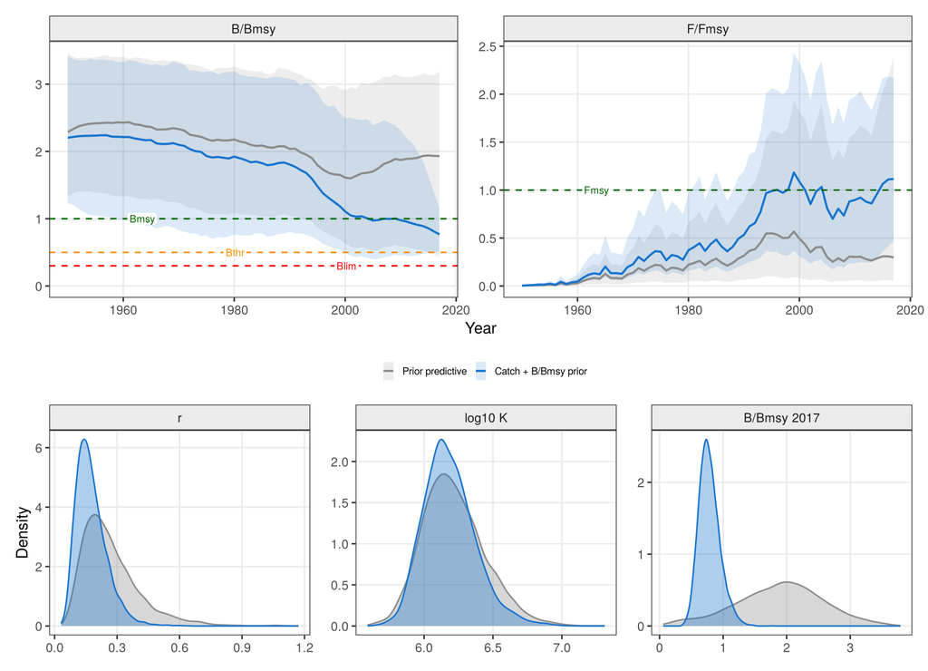

```r
jbplot_priorpost_trj(list(`Prior predictive` = co.ppm, `Catch + B/Bmsy prior` = co.b))
```

The prior predictive run is the reality check: with the catch and the default priors alone, bigeye would be lightly exploited ($B/B_{MSY}$ around 2 in 2017, $P(B < B_{MSY}) < 0.1$), with a wide interval. This is driven by the default K prior (8 times the maximum catch) and initial depletion near unfished: with a large K, the catch history barely dents the biomass. The prior predictive run makes such implications visible before any data are fitted. The terminal-year status prior pulls $B/B_{MSY}$ down to its median of 0.7 and, through the catch, also the recent trajectory, K and r; but the result is only as good as the prior.

## 18.3 Catch + auxiliary data

Auxiliary data enter `jb3_data()` as a data frame (one column per series, with `auxiliary.type`) or as a named list of series. The observation model is lognormal, with the input log-scale SE plus an additional observation SD estimated per series (`jb3_model(aux.sd = NULL)`, the default) or fixed (`aux.sd = 0.15`):

- **effort**: $\log E_t \sim N(\log F_t - \log q_E - (t - t_0)\log(1 + c),\ \sigma^2)$, where $c$ is the annual effort creep (the increase in catchability per unit effort). The creep is fixed with `jb3_model(effort.creep = 0.02)` or estimated with `effort.creep = "estimate"` and a normal prior `jb3_priors(creep = c(0.02, 0.02))`. $q_E$ is estimated.
- **ffmsy, bbmsy, bk**: the status quantity itself with $q = 1$ (absolute status estimates, e.g. from length-based indicators or another assessment; set `aux.q = NA` to estimate a scaling instead);
- **f** ($q = 1$) and **z** (estimated $q$, as JABBA).

The hypothetical bigeye series:

```r
head(bet$effort_hyp, 3)
```

```
#>   year effort
#> 1 1960  89.51
#> 2 1961 143.10
#> 3 1962 210.60
```

```r
head(bet$ffmsy_hyp, 3)
```

```
#>   year  ffmsy  se
#> 1 1990 0.4797 0.3
#> 2 1991 0.7083 0.3
#> 3 1992 0.9433 0.3
```

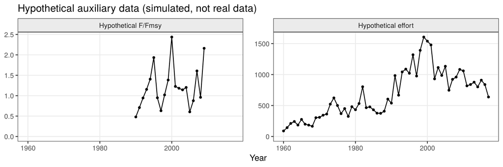

```r
ax <- rbind(data.frame(year = bet$effort_hyp$year, value = bet$effort_hyp$effort, series = "Hypothetical effort"),
            data.frame(year = bet$ffmsy_hyp$year, value = bet$ffmsy_hyp$ffmsy, series = "Hypothetical F/Fmsy"))
ggplot2::ggplot(ax, ggplot2::aes(year, value)) + ggplot2::geom_line() + ggplot2::geom_point(size = 1) +
  ggplot2::facet_wrap(~series, scales = "free_y") + ggplot2::expand_limits(y = 0) +
  ggplot2::labs(x = "Year", y = NULL, title = "Hypothetical auxiliary data (simulated, not real data)") + theme_jabba3()
```

Catch + hypothetical effort, with the 2% creep it was simulated with, and with no creep as a sensitivity:

```r
d.e <- jb3_data(bet$catch, NULL, stock = "bet", auxiliary = bet$effort_hyp, auxiliary.type = "effort")
d.e
```

```
#> JABBA3 data:bet
#>   years 1950-2017 (68), catch range 808-135000
#>   catch-only: no abundance index
#>   auxiliary effort (effort): 58 obs, 1960-2017
```

```r
co.e  <- jabba3(d.e, pr0, jb3_model(shape = "fox", effort.creep = 0.02), nuts = nu, run = "Catch + effort (creep 2%)")
co.e0 <- jabba3(d.e, pr0, jb3_model(shape = "fox", effort.creep = 0),    nuts = nu, run = "Catch + effort (no creep)")
```

Catch + hypothetical F/Fmsy index, 1990-2009 only, with its SE of 0.3:

```r
d.f <- jb3_data(bet$catch, NULL, stock = "bet", auxiliary = bet$ffmsy_hyp[, c("year", "ffmsy")],
                auxiliary.se = bet$ffmsy_hyp[, c("year", "se")], auxiliary.type = "ffmsy")
co.f <- jabba3(d.f, pr0, mod, nuts = nu, run = "Catch + F/Fmsy index")
```

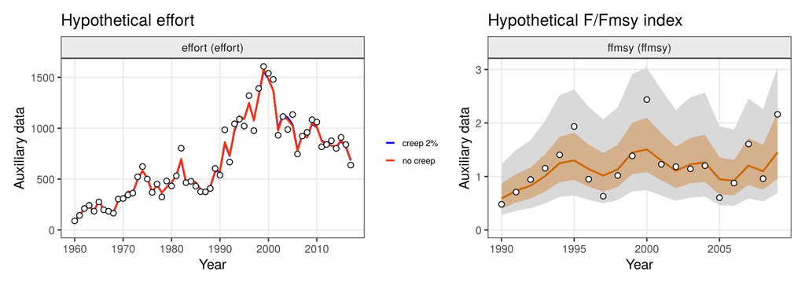

```r
patchwork::wrap_plots(
  jbplot_auxfits(list(`creep 2%` = co.e, `no creep` = co.e0), title = "Hypothetical effort"),
  jbplot_auxfits(co.f, title = "Hypothetical F/Fmsy index"), ncol = 2, widths = c(1, 1))
```

Effort informs the *trend* in F, not its scale ($q_E$ is estimated), and the creep assumption is decisive: without creep, the same nominal effort implies a steadily falling F in recent years, and the stock looks lightly exploited ($B/B_{MSY}$ about 2 in 2017). With the 2% creep the series was simulated with, the estimate is close to the index-based assessment, which is partly by construction (the effort was simulated from that assessment’s F). An absolute F/Fmsy index informs the *scale* of exploitation: in 1990-2009 the F/Fmsy estimates of the catch + F/Fmsy run are about as precise as those of the index-based run. After 2009 there is no information on F, and the terminal F/Fmsy interval widens again.

## 18.4 Catch + index, and catch + auxiliary data + index

```r
d.i  <- jb3_data(bet$catch, bet$cpue, bet$se, stock = "bet")
co.i <- jabba3(d.i, jb3_priors(d.i, r = pr.r), mod, engine = "nuts", nuts = nu, run = "Catch + index")
d.ie <- jb3_data(bet$catch, bet$cpue, bet$se, stock = "bet",
                 auxiliary = bet$effort_hyp, auxiliary.type = "effort")
co.ie <- jabba3(d.ie, jb3_priors(d.ie, r = pr.r), jb3_model(shape = "fox", effort.creep = 0.02),
                engine = "nuts", nuts = nu, run = "Catch + effort + index")
```

## 18.5 Moving up the tiers

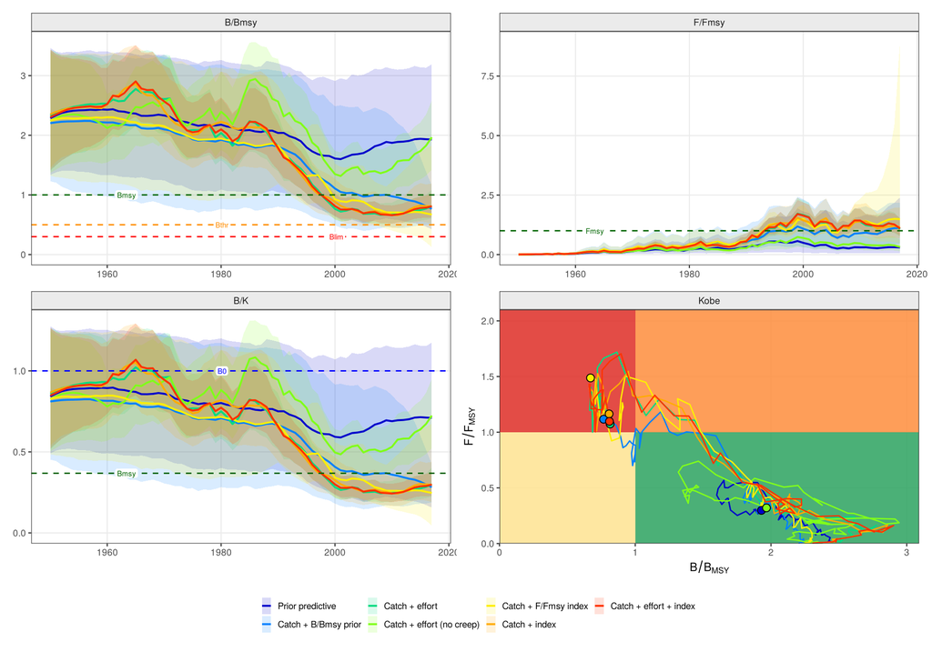

```r
co.runs <- list(`Prior predictive` = co.ppm, `Catch + B/Bmsy prior` = co.b, `Catch + effort` = co.e,
                `Catch + effort (no creep)` = co.e0, `Catch + F/Fmsy index` = co.f, `Catch + index` = co.i,
                `Catch + effort + index` = co.ie)
jabbaplot3(co.runs, panels = c("B/Bmsy", "F/Fmsy", "B/K", "kobe"), ncol = 2)
```

```r
pt <- jb3_partable(co.runs, format = "wide")
knitr::kable(pt[pt$Parameter %in% c("K", "r", "MSY", "qA.effort", "sdA.effort", "sdA.ffmsy", "B/Bmsy", "F/Fmsy"), ],
             row.names = FALSE, caption = "Posterior medians (95% intervals); the effort and F/Fmsy data are hypothetical")
```

Posterior medians (95% intervals); the effort and F/Fmsy data are hypothetical

| Parameter | Prior predictive | Catch + B/Bmsy prior | Catch + effort | Catch + effort (no creep) | Catch + F/Fmsy index | Catch + index | Catch + effort + index |
| --- | --- | --- | --- | --- | --- | --- | --- |
| K | 1,560,000 (680,000-5,180,000) | 1,470,000 (734,000-4,180,000) | 1,270,000 (770,000-2,420,000) | 1,720,000 (910,000-4,320,000) | 1,370,000 (751,000-2,840,000) | 1,380,000 (828,000-2,670,000) | 1,330,000 (817,000-2,510,000) |
| r | 0.24 (0.0932-0.626) | 0.164 (0.0727-0.353) | 0.179 (0.0893-0.306) | 0.183 (0.0892-0.329) | 0.152 (0.072-0.306) | 0.164 (0.0799-0.285) | 0.167 (0.0831-0.286) |
| MSY | 131,000 (68,700-514,000) | 89,100 (57,300-178,000) | 83,600 (65,900-104,000) | 115,000 (71,600-233,000) | 78,300 (52,800-107,000) | 83,300 (64,000-105,000) | 82,400 (65,600-98,900) |
| B/Bmsy | 1.93 (0.425-3.19) | 0.767 (0.512-1.16) | 0.815 (0.605-1.09) | 1.97 (1.42-2.58) | 0.671 (0.122-1.83) | 0.807 (0.518-1.19) | 0.81 (0.622-1.03) |
| F/Fmsy | 0.298 (0.0569- 2.4) | 1.12 (0.462-2.17) | 1.07 (0.753-1.53) | 0.32 (0.139-0.626) | 1.49 (0.483-8.93) | 1.16 (0.678-1.98) | 1.1 (0.795-1.52) |
| qA.effort |  |  | 0.0000912 (0.0000453-0.000153) | 0.0000852 (0.0000317-0.000174) |  |  | 0.0000858 (0.0000446-0.000146) |
| sdA.effort |  |  | 0.0477 (0.0203-0.102) | 0.0467 (0.0203-0.102) |  |  | 0.0476 (0.0205-0.102) |
| sdA.ffmsy |  |  |  |  | 0.0921 (0.0247-0.305) |  |  |

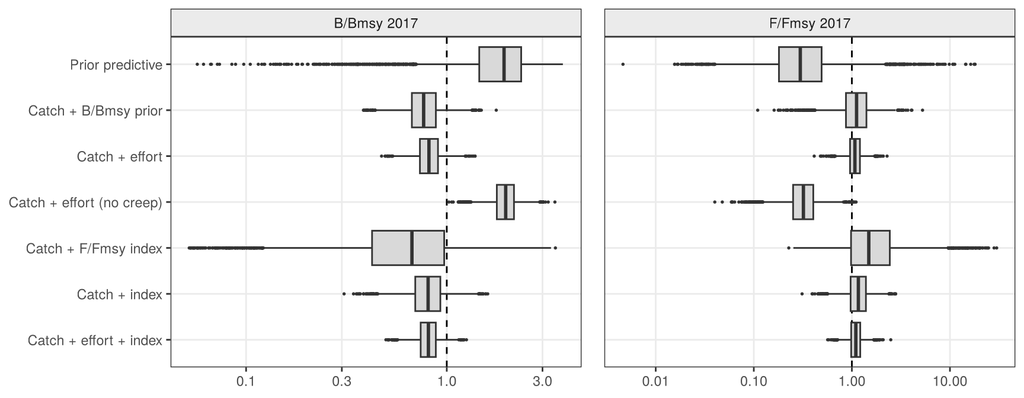

```r
stat <- do.call(rbind, lapply(names(co.runs), function(n){ f <- co.runs[[n]]; ly <- as.character(max(f$years))
  rbind(data.frame(run = n, quantity = "B/Bmsy 2017", value = f$draws$`B/Bmsy`[, ly]),
        data.frame(run = n, quantity = "F/Fmsy 2017", value = f$draws$`F/Fmsy`[, ly])) }))
stat$run <- factor(stat$run, rev(names(co.runs)))
ggplot2::ggplot(stat, ggplot2::aes(value, run)) + ggplot2::geom_vline(xintercept = 1, linetype = 2) +
  ggplot2::geom_boxplot(outlier.size = 0.3, fill = "grey85") + ggplot2::scale_x_log10() +
  ggplot2::facet_wrap(~quantity, scales = "free_x") + ggplot2::labs(x = NULL, y = NULL) + theme_jabba3()
```

The probability of being overfished, $P(B < B_{MSY})$, and of overfishing, $P(F > F_{MSY})$, in 2017:

```r
knitr::kable(do.call(rbind, lapply(names(co.runs), function(n){ f <- co.runs[[n]]
  data.frame(run = n, `P(B<Bmsy)` = mean(f$draws$`B/Bmsy`[, "2017"] < 1), `P(F>Fmsy)` = mean(f$draws$`F/Fmsy`[, "2017"] > 1),
             check.names = FALSE) })), digits = 2)
```

| run | P(B<Bmsy) | P(F>Fmsy) |
| --- | --- | --- |
| Prior predictive | 0.10 | 0.08 |
| Catch + B/Bmsy prior | 0.90 | 0.62 |
| Catch + effort | 0.91 | 0.66 |
| Catch + effort (no creep) | 0.00 | 0.00 |
| Catch + F/Fmsy index | 0.77 | 0.74 |
| Catch + index | 0.85 | 0.71 |
| Catch + effort + index | 0.96 | 0.72 |

Prior against posterior for the full assessment (catch + effort + index), with the prior predictive run as the reference:

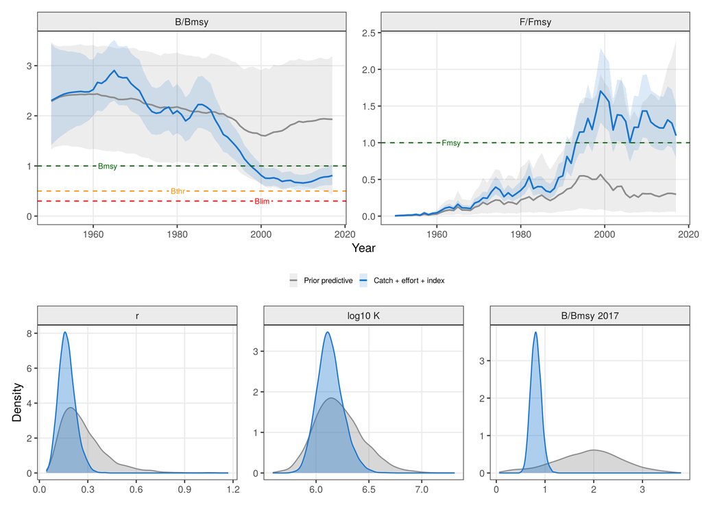

```r
jbplot_priorpost_trj(co.ppm, co.ie, labels = c("Prior predictive", "Catch + effort + index"))
```

Moving up the tiers changes the classification of the stock. The prior predictive run classifies bigeye as not overfished ($P(B < B_{MSY}) < 0.1$); every run with information on the exploitation history, whether a status prior, effort with creep, an F/Fmsy index or the CPUE indices, classifies it as overfished with probability 0.75-0.96, with similar medians of $B/B_{MSY}$ around 0.7-0.8. They differ in precision. The status prior fixes the terminal estimate wherever the prior is placed, so its value lies entirely in how well the prior is founded. The hypothetical F/Fmsy index covers only 20 years of high exploitation, yet moves the classification from “not overfished” to “overfished”, as Kell et al. (2025) found for auxiliary F/Fmsy indices from periods of high exploitation; without information after 2009 its terminal interval stays wide. Effort carries the trend in exploitation, but its result depends on the assumed creep, which should be treated as a key uncertainty (fixed scenarios, or estimated with an informed prior). With the CPUE indices, the effort narrows the interval of $B/B_{MSY}$ somewhat, but here the agreement is partly built in, because the hypothetical effort was simulated from the index-based assessment.

## 18.6 How much do the data add? Prior-posterior contraction

The prior predictive run is also the reference for a diagnostic of what each tier adds. `jb3_contraction()` compares each quantity of a fit with the prior predictive run (log scale):

- **contraction** = 1 − var(posterior)/var(prior predictive), the share of the prior uncertainty removed by the data (0: the data add nothing; 1: fully determined by the data);
- **shift** = (mean(posterior) − mean(prior predictive))/sd(prior predictive), how far the data move the estimate, in prior SDs.

Low contraction means a quantity is prior-driven; a large shift means the data pull it into the tail of the prior (prior-data conflict); high contraction with a moderate shift means it is informed by the data.

> **Source.** The diagnostic is adapted from the *posterior shrinkage* versus *posterior z-score* plot of Betancourt (2018), part of the principled Bayesian workflow of Schad et al. (2021). Betancourt computes shrinkage $= 1 - \mathrm{var(posterior)}/\mathrm{var(prior)}$ and the z-score $=(\mathrm{mean(posterior)} - \theta_{true})/\mathrm{sd(posterior)}$ over simulated data sets with a known true value $\theta_{true}$, to check a model design before it is fitted to real data. A real assessment has no true value, so JABBA3 replaces the z-score by the shift from the prior predictive mean, which measures prior-data conflict rather than calibration, and uses the prior predictive run as the reference distribution; `contraction.pdf`, against the stated prior density, is the version closest to Betancourt’s shrinkage. The class names and the thresholds (`contraction.min = 0.25`, `shift.max = 2`) are JABBA3 choices, not from these papers. In simulation testing, where the truth is known, Betancourt’s original form applies directly. By default the prior predictive run is made with the fit’s own priors, model and catch (`jb3_contraction(fit)` runs it with NUTS). Here all runs are compared with the common prior predictive run `co.ppm` (catch and the r, K and initial-depletion priors), so that the status prior is treated as one of the tiers:

```r
ct <- jb3_contraction(co.runs[-1], prior = rep(list(co.ppm), length(co.runs) - 1), years = c(1990, 2017))
w <- reshape(as.data.frame(ct)[c("run", "quantity", "contraction")], idvar = "quantity", timevar = "run", direction = "wide")
names(w) <- sub("^contraction\\.", "", names(w))
knitr::kable(w, digits = 2, row.names = FALSE, caption = "Contraction relative to the prior predictive run")
```

Contraction relative to the prior predictive run

| quantity | Catch + B/Bmsy prior | Catch + effort | Catch + effort (no creep) | Catch + F/Fmsy index | Catch + index | Catch + effort + index |
| --- | --- | --- | --- | --- | --- | --- |
| K | 0.30 | 0.68 | 0.44 | 0.57 | 0.65 | 0.71 |
| r | 0.30 | 0.57 | 0.52 | 0.41 | 0.54 | 0.59 |
| MSY | 0.71 | 0.95 | 0.67 | 0.88 | 0.94 | 0.96 |
| bkinit | -0.06 | -0.01 | -0.01 | 0.01 | 0.05 | -0.03 |
| B/Bmsy 1990 | -0.42 | 0.79 | 0.76 | 0.38 | 0.59 | 0.84 |
| B/Bmsy 2017 | 0.82 | 0.91 | 0.91 | -0.88 | 0.81 | 0.93 |
| F/Fmsy 1990 | 0.60 | 0.94 | 0.69 | 0.92 | 0.88 | 0.95 |
| F/Fmsy 2017 | 0.81 | 0.96 | 0.81 | 0.32 | 0.90 | 0.97 |

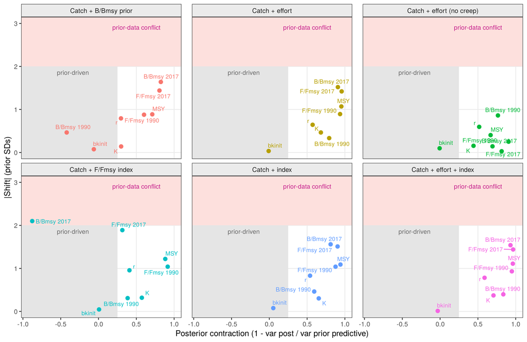

```r
jbplot_contraction(ct)
```

The initial depletion is prior-driven in every run: no tier informs it. All tiers with information on exploitation remove most of the prior uncertainty in terminal status (contraction 0.8-0.9) and move it by about 1.5 prior SDs towards overfished, which says that the default priors (K of 8 times the maximum catch, an unfished start) are optimistic for bigeye. The tiers differ in *where* they inform: the terminal status prior contracts only the terminal year, whereas $B/B_{MSY}$ in 1990 is not informed at all (contraction about −0.4); effort and the indices inform the whole trajectory. The hypothetical F/Fmsy index informs F/Fmsy in 1990 (0.92) but not the terminal status: its posterior for $B/B_{MSY}$ in 2017 is *wider* than the prior predictive (contraction −0.88) and shifted by more than two prior SDs, a flag that the auxiliary data move the stock into a region the rest of the model constrains poorly.

A catch-only fit compared with *its own* prior predictive run, which keeps the status prior, has a contraction of zero by construction, and the diagnostic says so:

```r
cb <- jb3_contraction(co.b, nuts = nu)
knitr::kable(as.data.frame(cb)[c("quantity", "prior.median", "post.median", "contraction", "contraction.pdf", "class")],
             digits = 3, row.names = FALSE)
```

| quantity | prior.median | post.median | contraction | contraction.pdf | class |
| --- | --- | --- | --- | --- | --- |
| K | 1.46e+06 | 1.47e+06 | -0.070 | 0.726 | prior-driven |
| r | 1.64e-01 | 1.64e-01 | -0.053 | 0.337 | prior-driven |
| MSY | 8.79e+04 | 8.91e+04 | -0.136 | NA | prior-driven |
| bkinit | 8.48e-01 | 8.40e-01 | -0.035 | 0.159 | prior-driven |
| B/Bmsy 2017 | 7.62e-01 | 7.67e-01 | -0.050 | NA | prior-driven |
| F/Fmsy 2017 | 1.14e+00 | 1.12e+00 | -0.076 | NA | prior-driven |

`contraction.pdf` compares the posterior of r, K and initial depletion with the stated prior density rather than with the prior predictive run. It shows what the catch and the status prior do to the r and K priors even without any data: the variance of log K is reduced by about 75% and that of log r by about 35%, because only combinations under which the stock survives the catch history and ends near the status prior remain (the CMSY logic). This is a check of the priors (whether much of the prior is incompatible with the catch), not a reason to narrow them: using the catch-conditioned r and K as priors would count the catch twice.

## 18.7 Non-centred process deviations

When the data say little about the states, as in a catch-only run, the process deviations and their SD form a “funnel” that NUTS samples poorly in the usual (centred) form. In the non-centred form NUTS samples standard normal innovations $z_t \sim N(0, 1)$ instead, and the deviations follow from

$$d_t = \rho\, d_{t-1} + \sigma_t \sqrt{1 - \rho^2}\, z_t,
\qquad \log P_t = \log \bar P_t + d_t,$$

with the production lag, bias correction, random walk and depletion-dependent SD exactly as in the centred form (the model is the same; only the coordinates of the sampler change). It is selected with `jb3_model(param = "noncentred")`; the default is `"centred"`, and the posterior mode always uses the centred form, where the Laplace approximation needs the states themselves. `jb3_nuts_ess()` gives the bulk and tail ESS of the derived states, also per 1000 draws, to compare the two:

```r
ess <- function(d, pr, p, ...) attr(jb3_nuts_ess(jabba3(d, pr, jb3_model(shape = "fox", param = p), nuts = nu, ...)), "summary")
rbind(ess(d.i, jb3_priors(d.i, r = pr.r), "centred", engine = "nuts"), ess(d.i, jb3_priors(d.i, r = pr.r), "noncentred", engine = "nuts"),
      ess(d0, pr.b, "centred"), ess(d0, pr.b, "noncentred"))
```

| Data | Form | min / median bulk ESS per 1000 draws, B/Bmsy | min tail ESS per 1000, B/Bmsy | Divergent transitions | Run time (s) |
| --- | --- | --- | --- | --- | --- |
| catch + index | centred | 43 / 54 | 92 | 0 | 33 |
| catch + index | non-centred | 113 / 327 | 42 | 1016 | 227 |
| catch + B/Bmsy prior | centred | 72 / 134 | 108 | 0 | 23 |
| catch + B/Bmsy prior | non-centred | 313 / 813 | 133 | 394 | 280 |

*Three chains of 2000 iterations (3000 post-warm-up draws); F/Fmsy behaves the same way.*

The non-centred form gives a higher bulk ESS per draw, but many divergent transitions, so its draws are not reliable, and it is seven to twelve times slower. The reason is the production model: each state depends on *all* earlier innovations through the nonlinear surplus production and the catch removals, so the non-centred coordinates are strongly and nonlinearly correlated, and the curvature changes sharply where the catch approaches the biomass. The centred form had no divergences in either case and is the default. The non-centred form remains an option for short series or very weakly informed states, always to be checked with `jb3_nuts_diags()`.

# 19 FLR outputs

`jb3_flqs()` returns the time series as `FLQuants` (`stock` = B/Bmsy, `harvest` = F/Fmsy, `biomass`, `F` and `catch`), with the draws as iterations when the fit has draws; `jb3_flpar()` returns parameters, reference points and current status as an `FLPar`.

```r
fq <- jb3_flqs(fit)
names(fq)
```

```
#> [1] "stock"   "harvest" "biomass" "F"       "catch"
```

```r
dim(fq$stock)
```

```
#> [1]    1   68    1    1    1 1000
```

```r
jb3_flpar(fit)
```

```
#> An object of class "FLPar"
#> params
#>        K        r        m     Bmsy     Fmsy      MSY    BmsyK      sdb
#> 1.17e+06 1.93e-01 1.00e+00 4.32e+05 1.93e-01 8.33e+04 3.68e-01 9.45e-02
#>   B.Bmsy   F.Fmsy
#> 7.97e-01 1.16e+00
#> units:  NA NA NA NA NA NA NA NA NA NA
```

These plot with ggplotFL and can be used in FLR workflows (e.g. as the output of an estimator in `mse`):

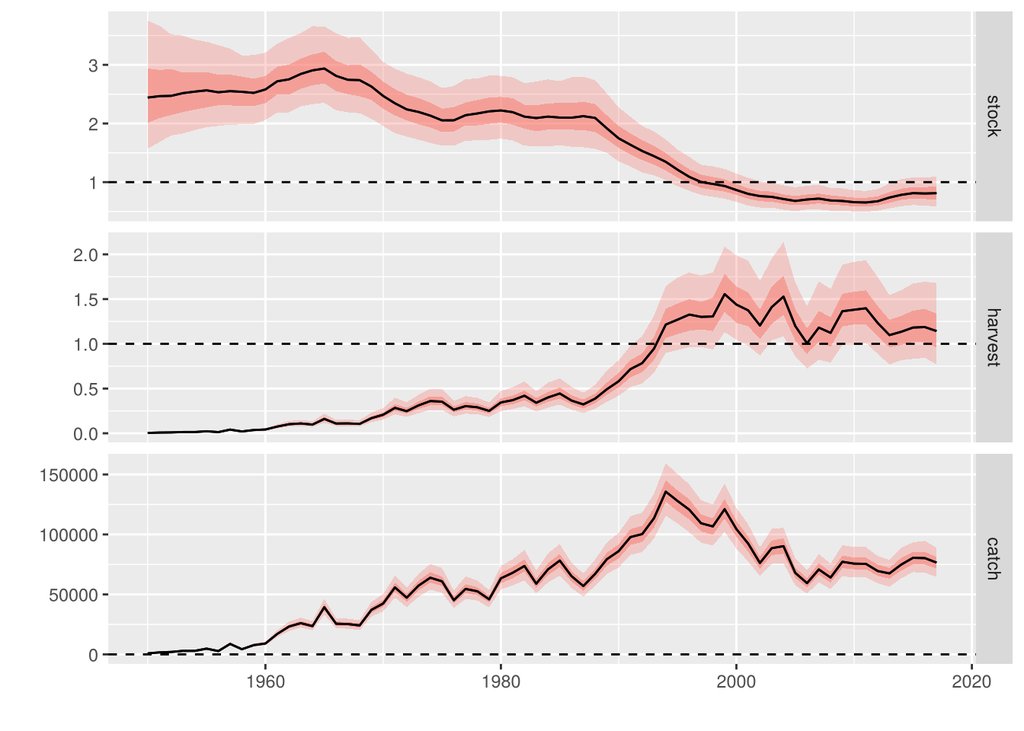

```r
library(ggplotFL)
plot(fq[c("stock", "harvest", "catch")]) + ggplot2::geom_hline(yintercept = 1, linetype = 2)
```

## 19.1 FLStockR

`jb3_FLStockR()` converts the fit to a biomass-dynamic `FLStockR`, as `FLRef::jabba2FLStockR()`: biomass in `stock` (and `ssb()`), catch, and the harvest rate in `harvest`, with the draws as iterations. The `refpts` slot holds $F_{MSY}$, $B_{MSY}$, MSY, $B_{thr}$ and $B_{lim}$ (by default 0.5 and 0.3 $B_{MSY}$, the SPiCT benchmark defaults) and $B_0$. Advice from surplus production models is given in relative terms, so by default the stock is in $B/B_{MSY}$ and $F/F_{MSY}$; `rel = FALSE` gives absolute biomass and harvest rate.

```r
stk <- jb3_FLStockR(fit, ndraws = 500)        # relative (B/Bmsy, F/Fmsy) by default
stk@refpts
```

```
#> An object of class "FLPar"
#> params
#>     Fmsy     Bmsy      MSY     Bthr     Blim       B0
#>     1.00     1.00 83335.26     0.50     0.30     2.72
#> units:  NA
```

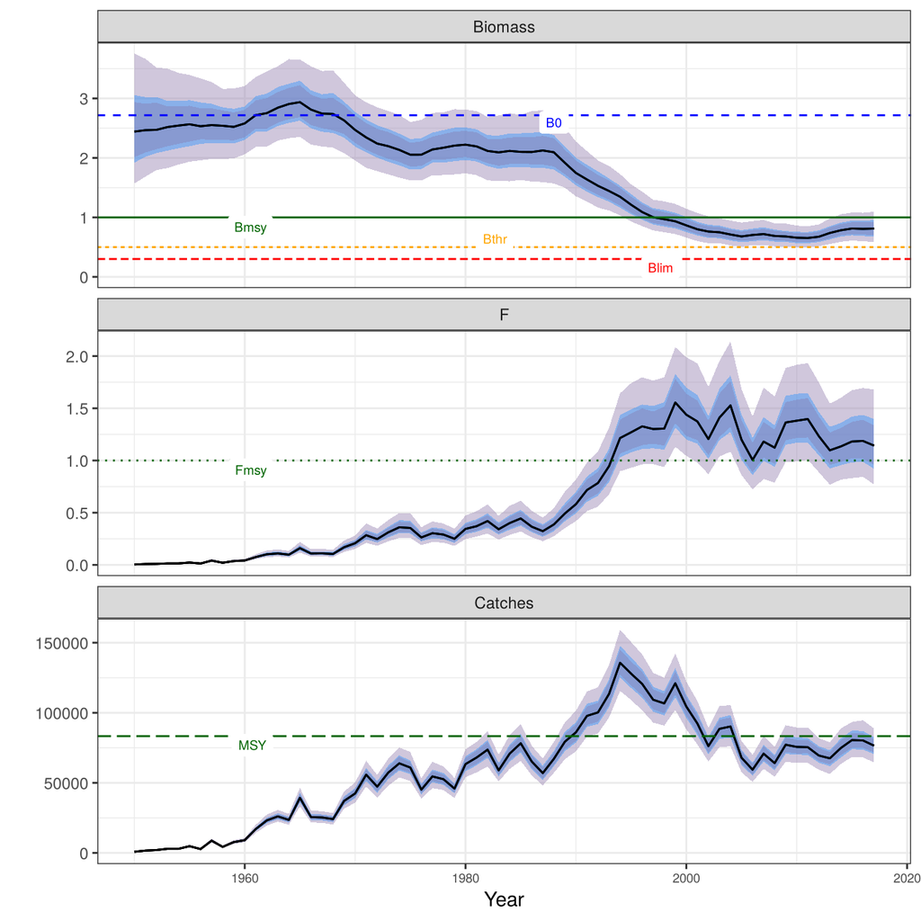

```r
FLRef::plotAdvice(stk, type = "spm") + ggplot2::facet_wrap(~qname, ncol = 1, scales = "free_y")
```

Absolute biomass and harvest rate with `rel = FALSE`:

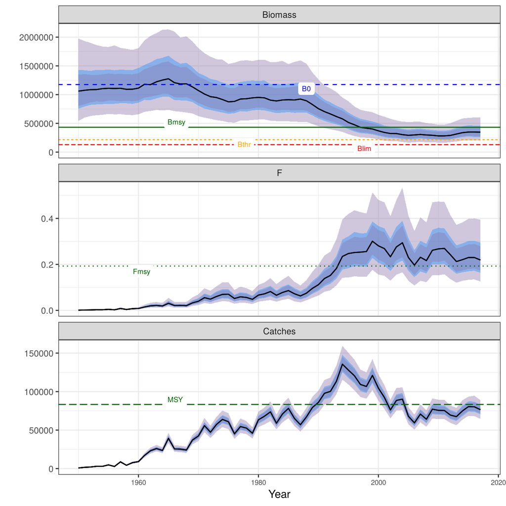

```r
FLRef::plotAdvice(jb3_FLStockR(fit, rel = FALSE, ndraws = 500), type = "spm") +
  ggplot2::facet_wrap(~qname, ncol = 1, scales = "free_y")
```

# 20 Converting from JABBA and SPiCT

## 20.1 JABBA: `jbinput2jabba3()`

`jbinput2jabba3()` takes the object returned by `JABBA::build_jabba()` and returns `list(data, priors, model)` for `jabba3()`. It carries over the priors (r, K, psi to `bkinit`, shape, catchability, status priors), the production lag, catch error, catchability and variance groups, `proc.dev.all`, the BioProcDyn process-error options and the Selex curves, and reports each difference:

- JABBA’s inverse-gamma prior on the process variance is replaced by the FishLife prior (`keep.igamma = TRUE` keeps it);
- q gets a flat prior on log q (`q.uniform = TRUE` reproduces the JAGS uniform prior on q);
- auxiliary data are not yet supported and are dropped.

```r
jb <- JABBA::build_jabba(catch = bet$catch, cpue = bet$cpue, se = bet$se, model.type = "Fox",
                         r.prior = c(0.2, 0.5), psi.prior = c(0.9, 0.25), verbose = FALSE)
options(scipen = 0)          # build_jabba() sets options(scipen = 999)
x  <- jbinput2jabba3(jb)
f2 <- jabba3(x$data, x$priors, x$model, osa = FALSE)
signif(f2$pars[c("K", "r", "sdb"), c("est", "lci", "uci")], 4)
```

```
#>           est       lci       uci
#> K   1.175e+06 6.887e+05 2.004e+06
#> r   1.929e-01 1.068e-01 3.486e-01
#> sdb 9.452e-02 6.314e-02 1.415e-01
```

> With the same process-error prior, the conversion reproduces the JABBA (RTMB engine) fit of bigeye exactly (K = 1,174,749; $B/B_{MSY}$ = 0.797 in 2017).

## 20.2 SPiCT: `spictinp2jabba3()`

`spictinp2jabba3()` takes a SPiCT input list (`inp`, as passed to `spict::fit.spict()`). JABBA3 is an annual model: catches are summed by calendar year and several index observations in a year are averaged (geometric mean). SPiCT’s observation-error form is used (`obs.error = "spict"`), with `stdevfacI` as relative weights. The priors `logr`, `logK`, `logbkfrac`, `logsdb`, `logn` and `logsdi` carry over with their on/off switches, and a fixed `n` (phase -1) fixes the shape. The `alpha` and `beta` priors (ratios of observation to process SDs) and the F process have no JABBA3 equivalent and are reported as dropped.

A SPiCT-style input list built from the bigeye data:

```r
ok1 <- is.finite(bet$cpue[, 2]); ok2 <- is.finite(bet$cpue[, 3])
inp <- list(obsC = bet$catch[, 2], timeC = bet$catch[, 1],
            obsI = list(bet$cpue[ok1, 2], bet$cpue[ok2, 3]),
            timeI = list(bet$cpue[ok1, 1] + 0.5, bet$cpue[ok2, 1] + 0.5),
            priors = list(logr = c(log(0.2), 0.5, 1), logn = c(log(2), 2, 0), logbkfrac = c(log(0.8), 0.5, 1)),
            ini = list(logn = log(2)), phases = list(logn = -1))
xs <- spictinp2jabba3(inp, stock = "bet")
fs <- jabba3(xs$data, xs$priors, xs$model, osa = FALSE)
signif(fs$pars[c("K", "r", "sdb"), c("est", "lci", "uci")], 4)
```

```
#>           est       lci       uci
#> K   1.566e+06 7.260e+05 3.377e+06
#> r   2.352e-01 1.028e-01 5.382e-01
#> sdb 1.292e-01 1.049e-01 1.593e-01
```

With the spict package installed, its example data convert the same way:

```r
data(pol, package = "spict")
xp <- spictinp2jabba3(pol$albacore, stock = "albacore")
fp <- jabba3(xp$data, xp$priors, xp$model)
fp
```

# 21 Model equations

**Process equation.** Biomass relative to K, $P_t = B_t/K$, with process error acting after the catch (Winker et al. 2018) and a production lag $L$:

$$\log P_t = \log\left[P_{t-1} + \frac{r}{m-1} P_{t-1-L}\left(1 - P_{t-1-L}^{\,m-1}\right) - \frac{C_{t-1}}{K}\right] + d_t ,$$

where $m$ is the Pella-Tomlinson shape ($m = 2$ Schaefer, $m \to 1$ Fox) and $P_1$ = `bkinit`. Years before the start use the initial depletion for the lagged term.

**Process deviations.** Stationary AR(1), with $\sigma_t$ the marginal SD:

$$d_1 \sim N(0, \sigma_1^2), \qquad d_t \sim N\left(\rho\, d_{t-1},\ \sigma_t^2 (1-\rho^2)\right),$$

$\rho = 0$ giving the independent process error of JABBA and SPiCT. Either $\sigma_t = \sigma_{MSY}$ (constant) or $\sigma_t = \sigma_{MSY} x_t^{-k}$ with $x_t = B_t/B_{MSY}$ bounded to `xlim` (dynamic).

**Reference points.**

$$\frac{B_{MSY}}{K} = m^{-1/(m-1)}, \qquad F_{MSY} = \frac{r}{m}, \qquad MSY = F_{MSY} B_{MSY}.$$

**Observations.** Index $i$ in year $t$:

$$\log I_{i,t} = \log q_i + \log(K P_t) + \varepsilon_{i,t}, \qquad
\varepsilon_{i,t} \sim N\left(0,\ se_{i,t}^2 + sdi_i^2\right)$$

(`obs.error = "additive"`), or $\varepsilon_{i,t} \sim N(0, (sdi_i\,w_{i,t})^2)$ (`obs.error = "spict"`). Catch: $\log C^{obs}_t \sim N(\log C_t, sdc^2)$ when `catch.error = TRUE`.

**Estimation.** The states $\log P_t$ and catch deviations are random effects, integrated by the Laplace approximation (`engine = "rtmb"`) or sampled with the fixed effects (`engine = "nuts"`).

# 22 Summary of checks and functions

| # | Check | Red flag | Action |
| --- | --- | --- | --- |
| 1 | data (`jbplot_data`) | no contrast; conflicting indices | r prior, status priors; separate `sdi`; sensitivity runs |
| 2 | prior and posterior (`jbplot_priorpost`) | posterior = prior; posterior at the edge | report; revisit priors |
| 3 | convergence (`jb3_convergence`) | gradient, Hessian, Newton decrement | restarts; priors on r or K; fewer groups |
| 4 | residuals (`jbplot_residuals`, `jbplot_runs`, `jb3_diags`) | trends, failed runs or Ljung-Box tests | lag + AR(1); index conflict |
| 5 | retrospective (`jb3_retro`) | Mohn’s rho beyond -0.15 to 0.20 | recent data, q |
| 6 | hindcast (`jb3_hindcast`) | MASE > 1 | index without prediction skill |
| 7 | process deviations (`jbplot_procdev`) | long runs of one sign | `rho = 0.75`, `lag = amat` |
| 8 | NUTS (`jb3_nuts_diags`, `jbplot_nuts`) | $\hat{R} > 1.01$, low ESS, divergences, E-BFMI < 0.3 | longer chains; `adapt_delta`; priors |

| Topic | Recommendation |
| --- | --- |
| Process error | lag at the age at maturity + AR(1) with $\rho = 0.75$ (sensitivity 0.5, 0.9); FishLife prior on $\sigma_{MSY}$ |
| Shape | Pella with $B_{MSY}/K = 0.4$ unless known; convert the r prior with the shape |
| Engine | posterior mode for exploration, diagnostics, retro and hindcast; NUTS for final runs, and for catch-only and prior predictive runs |
| Data-limited | start with the prior predictive run (`prior.only = TRUE`); add status priors or auxiliary data and report how far each moves status |
| Simulation testing and MSE | `se = FALSE, osa = FALSE` |

## 22.1 Function reference

[output not shown]

*Planned: multi-fleet Selex, auxiliary-data lags (JABBA `auxiliary.lag`), a worked simulation-testing example.*

# 23 References

Betancourt, M. (2018). Calibrating model-based inferences and decisions. arXiv:1803.08393. https://arxiv.org/abs/1803.08393

Carvalho, F., Winker, H., Courtney, D., Kapur, M., Kell, L., Cardinale, M., Schirripa, M., Kitakado, T., Yemane, D., Piner, K.R., Maunder, M.N., Taylor, I., Wetzel, C.R., Doering, K., Johnson, K.F. and Methot, R.D. (2021). A cookbook for using model diagnostics in integrated stock assessments. *Fisheries Research* 240: 105959.

Conn, P.B. (2010). Hierarchical analysis of multiple noisy abundance indices. *Canadian Journal of Fisheries and Aquatic Sciences*, 67, 108-120. doi:10.1139/F09-175

Francis, R.I.C.C. (2011). Data weighting in statistical fisheries stock assessment models. *Canadian Journal of Fisheries and Aquatic Sciences*, 68, 1124-1138.

Kell, L.T., Cardinale, M., Mosqueira, I., Winker, H. and Sharma, R. (2025). Transforming data and capacity-limited stock assessment: achieving risk equivalence with hierarchical assessment frameworks and auxiliary data. *Sustainability* 17: 9383. doi:10.3390/su17219383

Kell, L.T., Mosqueira, I., Grosjean, P., Fromentin, J.-M., Garcia, D., Hillary, R., Jardim, E., Mardle, S., Pastoors, M.A., Poos, J.J., Scott, F. and Scott, R.D. (2007). FLR: an open-source framework for the evaluation and development of management strategies. *ICES Journal of Marine Science* 64(4): 640-646.

Kell, L.T., Sharma, R., Kitakado, T., Winker, H., Mosqueira, I., Cardinale, M. and Fu, D. (2021). Validation of stock assessment methods: is it me or my model talking? *ICES Journal of Marine Science* 78(6): 2244-2255.

Kristensen, K., Nielsen, A., Berg, C.W., Skaug, H. and Bell, B.M. (2016). TMB: automatic differentiation and Laplace approximation. *Journal of Statistical Software* 70(5): 1-21.

Monnahan, C.C. and Kristensen, K. (2018). No-U-turn sampling for fast Bayesian inference in ADMB and TMB: introducing the adnuts and tmbstan R packages. *PLoS ONE* 13(5): e0197954.

Pedersen, M.W. and Berg, C.W. (2017). A stochastic surplus production model in continuous time. *Fish and Fisheries* 18(2): 226-243.

Schad, D.J., Betancourt, M. and Vasishth, S. (2021). Toward a principled Bayesian workflow in cognitive science. *Psychological Methods*, 26, 103-126. Preprint: https://arxiv.org/abs/1904.12765

Sherley, R.B. et al. (2020). *Ecology and Evolution* (JARA census model applied to absolute abundance indices). doi:10.1002/ece3.6554

Thorson, J.T. (2020). Predicting recruitment density dependence and intrinsic growth rate for all fishes worldwide using a data-integrated life-history model. *Fish and Fisheries* 21(2): 237-251.

Thorson, J.T., Shelton, A.O., Ward, E.J. and Skaug, H.J. (2015). Geostatistical delta-generalized linear mixed models improve precision for estimated abundance indices for West Coast groundfishes. *ICES Journal of Marine Science*, 72, 1297-1310.

Thygesen, U.H., Albertsen, C.M., Berg, C.W., Kristensen, K. and Nielsen, A. (2017). Validation of ecological state space models using the Laplace approximation. *Environmental and Ecological Statistics* 24(2): 317-339.

Vehtari, A., Gelman, A., Simpson, D., Carpenter, B. and Bürkner, P.-C. (2021). Rank-normalization, folding, and localization: an improved $\hat{R}$ for assessing convergence of MCMC. *Bayesian Analysis* 16(2): 667-718.

Winker, H. et al. (2026). Process error in surplus production models: scale, persistence and inflation (BioProcDyn). In preparation.

Winker, H., Carvalho, F. and Kapur, M. (2018). JABBA: Just Another Bayesian Biomass Assessment. *Fisheries Research* 204: 275-288.

Winker, H., Thorson, J.T., Fairweather, T., Leslie, R. and Durholtz, D. (2017). Towards improving precision in South African demersal trawl survey indices using geostatistical GLMMs. MARAM/IWS/2017/Hake/BG8. University of Cape Town.